```r
library(tidyverse)
library(readxl)
library(skimr)
library(corrr)
library(rstanarm)
```

```r
library(bayestestR)
library(bayesplot)
library(tidymodels)
library(corrplot)
library(QuantPsyc)
options(mc.cores = parallel::detectCores())
```

```r
conflicted::conflict_prefer("select", "dplyr")
```

```
## [conflicted] Will prefer dplyr::select over any other package.
```

```r
conflicted::conflict_prefer("filter", "dplyr")
```

```
## [conflicted] Will prefer dplyr::filter over any other package.
```

# 1. Vorbereitung der Daten

## Daten einlesen

```r
d_raw <- read_excel("raw_data.xlsx")
```

## Unnötige Variablen entfernen

```r
raw1 <- d_raw %>%
  select(-c(CASE, SERIAL, REF, QUESTNNR, MODE, STARTED, TIME001:TIME012, MAILSENT, LASTDATA, FINISHED, Q_VIEWER, LASTPAGE, MAXPAGE, MISSREL, MISSING))
```

## Variablenbeschreibung (Zeile) entfernen

```r
raw1 = raw1[-1,]
```

## Spaltennamen umbenennen

```r
names(raw1) <- c("Alter", "Geschlecht", "Bildung", "Bildung_sonstig", "BZG_J", "BZG_M", "Beschaeftigungsart", "Arbeitszeitmodell", "Gehalt", "Position_im_Unternehmen", "Remotarbeit", "IS_K01", "IS_K02", "IS_K03", "IS_K04", "IS_E05", "IS_E06", "IS_E07", "IS_E08", "OC_A01", "OC_A02", "OC_A03", "OC_A04", "OC_A05", "CPE_C01", "CPE_C02", "CPE_C03", "CPE_C04", "CPE_I05", "CPE_I06", "CPE_I07", "CPE_I08", "CPE_M09", "CPE_M10", "CPE_M11", "CPE_M12", "CPE_E13", "CPE_E14", "CPE_E15", "CPE_E16", "PS_01", "PS_02", "PS_03", "PS_04", "PS_05", "PS_06", "PS_07", "QQ_01", "QQ_02", "QQ_03", "QQ_04", "QQ_05", "QQ_06", "QQ_07", "QQ_N08", "QQ_N09", "QQ_N10", "QQ_N11", "QQ_N12", "QQ_N13", "QQ_N14", "SL_01", "SL_02", "SL_03", "SL_04", "SL_05", "SL_06", "SL_07", "ZE01", "ZE04", "TIME_SUM", "TIME_RSI")
```

## ID-Spalte einfügen

```r
raw2 <- raw1 %>%
  mutate(ID = row_number()) %>%
  select(ID, everything())
```

## Kompletten Datensatz auf NA’s prüfen

```r
skim(raw2)
```

Data summary

| Name | raw2 |
| --- | --- |
| Number of rows | 192 |
| Number of columns | 73 |
| _______________________ |  |
| Column type frequency: |  |
| character | 72 |
| numeric | 1 |
| ________________________ |  |
| Group variables | None |

**Variable type: character**

| skim_variable | n_missing | complete_rate | min | max | empty | n_unique | whitespace |
| --- | --- | --- | --- | --- | --- | --- | --- |
| Alter | 2 | 0.99 | 2 | 2 | 0 | 39 | 0 |
| Geschlecht | 0 | 1.00 | 1 | 1 | 0 | 2 | 0 |
| Bildung | 0 | 1.00 | 1 | 1 | 0 | 8 | 0 |
| Bildung_sonstig | 189 | 0.02 | 12 | 17 | 0 | 3 | 0 |
| BZG_J | 0 | 1.00 | 1 | 2 | 0 | 38 | 0 |
| BZG_M | 5 | 0.97 | 1 | 2 | 0 | 12 | 0 |
| Beschaeftigungsart | 0 | 1.00 | 1 | 1 | 0 | 2 | 0 |
| Arbeitszeitmodell | 0 | 1.00 | 1 | 5 | 0 | 40 | 0 |
| Gehalt | 2 | 0.99 | 1 | 1 | 0 | 7 | 0 |
| Position_im_Unternehmen | 0 | 1.00 | 1 | 1 | 0 | 4 | 0 |
| Remotarbeit | 0 | 1.00 | 1 | 1 | 0 | 6 | 0 |
| IS_K01 | 0 | 1.00 | 1 | 1 | 0 | 7 | 0 |
| IS_K02 | 0 | 1.00 | 1 | 1 | 0 | 7 | 0 |
| IS_K03 | 0 | 1.00 | 1 | 1 | 0 | 7 | 0 |
| IS_K04 | 0 | 1.00 | 1 | 1 | 0 | 7 | 0 |
| IS_E05 | 0 | 1.00 | 1 | 1 | 0 | 7 | 0 |
| IS_E06 | 0 | 1.00 | 1 | 1 | 0 | 7 | 0 |
| IS_E07 | 0 | 1.00 | 1 | 1 | 0 | 7 | 0 |
| IS_E08 | 0 | 1.00 | 1 | 1 | 0 | 7 | 0 |
| OC_A01 | 0 | 1.00 | 1 | 1 | 0 | 5 | 0 |
| OC_A02 | 0 | 1.00 | 1 | 1 | 0 | 5 | 0 |
| OC_A03 | 0 | 1.00 | 1 | 1 | 0 | 5 | 0 |
| OC_A04 | 0 | 1.00 | 1 | 1 | 0 | 5 | 0 |
| OC_A05 | 0 | 1.00 | 1 | 1 | 0 | 5 | 0 |
| CPE_C01 | 0 | 1.00 | 1 | 1 | 0 | 7 | 0 |
| CPE_C02 | 0 | 1.00 | 1 | 1 | 0 | 7 | 0 |
| CPE_C03 | 0 | 1.00 | 1 | 1 | 0 | 7 | 0 |
| CPE_C04 | 0 | 1.00 | 1 | 1 | 0 | 7 | 0 |
| CPE_I05 | 0 | 1.00 | 1 | 1 | 0 | 7 | 0 |
| CPE_I06 | 0 | 1.00 | 1 | 1 | 0 | 7 | 0 |
| CPE_I07 | 0 | 1.00 | 1 | 1 | 0 | 7 | 0 |
| CPE_I08 | 0 | 1.00 | 1 | 1 | 0 | 7 | 0 |
| CPE_M09 | 0 | 1.00 | 1 | 1 | 0 | 7 | 0 |
| CPE_M10 | 0 | 1.00 | 1 | 1 | 0 | 7 | 0 |
| CPE_M11 | 1 | 0.99 | 1 | 1 | 0 | 7 | 0 |
| CPE_M12 | 0 | 1.00 | 1 | 1 | 0 | 7 | 0 |
| CPE_E13 | 0 | 1.00 | 1 | 1 | 0 | 7 | 0 |
| CPE_E14 | 0 | 1.00 | 1 | 1 | 0 | 7 | 0 |
| CPE_E15 | 0 | 1.00 | 1 | 1 | 0 | 7 | 0 |
| CPE_E16 | 0 | 1.00 | 1 | 1 | 0 | 7 | 0 |
| PS_01 | 0 | 1.00 | 1 | 1 | 0 | 7 | 0 |
| PS_02 | 0 | 1.00 | 1 | 1 | 0 | 7 | 0 |
| PS_03 | 0 | 1.00 | 1 | 1 | 0 | 7 | 0 |
| PS_04 | 0 | 1.00 | 1 | 1 | 0 | 7 | 0 |
| PS_05 | 0 | 1.00 | 1 | 1 | 0 | 7 | 0 |
| PS_06 | 0 | 1.00 | 1 | 1 | 0 | 7 | 0 |
| PS_07 | 0 | 1.00 | 1 | 1 | 0 | 7 | 0 |
| QQ_01 | 0 | 1.00 | 1 | 1 | 0 | 5 | 0 |
| QQ_02 | 0 | 1.00 | 1 | 1 | 0 | 5 | 0 |
| QQ_03 | 0 | 1.00 | 1 | 1 | 0 | 5 | 0 |
| QQ_04 | 0 | 1.00 | 1 | 1 | 0 | 5 | 0 |
| QQ_05 | 0 | 1.00 | 1 | 1 | 0 | 5 | 0 |
| QQ_06 | 0 | 1.00 | 1 | 1 | 0 | 5 | 0 |
| QQ_07 | 0 | 1.00 | 1 | 1 | 0 | 5 | 0 |
| QQ_N08 | 0 | 1.00 | 1 | 1 | 0 | 5 | 0 |
| QQ_N09 | 0 | 1.00 | 1 | 1 | 0 | 5 | 0 |
| QQ_N10 | 0 | 1.00 | 1 | 1 | 0 | 5 | 0 |
| QQ_N11 | 0 | 1.00 | 1 | 1 | 0 | 5 | 0 |
| QQ_N12 | 0 | 1.00 | 1 | 1 | 0 | 5 | 0 |
| QQ_N13 | 0 | 1.00 | 1 | 1 | 0 | 5 | 0 |
| QQ_N14 | 0 | 1.00 | 1 | 1 | 0 | 5 | 0 |
| SL_01 | 0 | 1.00 | 1 | 1 | 0 | 7 | 0 |
| SL_02 | 0 | 1.00 | 1 | 1 | 0 | 7 | 0 |
| SL_03 | 0 | 1.00 | 1 | 1 | 0 | 7 | 0 |
| SL_04 | 0 | 1.00 | 1 | 1 | 0 | 7 | 0 |
| SL_05 | 1 | 0.99 | 1 | 1 | 0 | 7 | 0 |
| SL_06 | 0 | 1.00 | 1 | 1 | 0 | 7 | 0 |
| SL_07 | 0 | 1.00 | 1 | 1 | 0 | 7 | 0 |
| ZE01 | 0 | 1.00 | 1 | 1 | 0 | 1 | 0 |
| ZE04 | 0 | 1.00 | 1 | 1 | 0 | 1 | 0 |
| TIME_SUM | 0 | 1.00 | 3 | 4 | 0 | 167 | 0 |
| TIME_RSI | 0 | 1.00 | 1 | 4 | 0 | 111 | 0 |

**Variable type: numeric**

| skim_variable | n_missing | complete_rate | mean | sd | p0 | p25 | p50 | p75 | p100 | hist |
| --- | --- | --- | --- | --- | --- | --- | --- | --- | --- | --- |
| ID | 0 | 1 | 96.5 | 55.57 | 1 | 48.75 | 96.5 | 144.25 | 192 | ▇▇▇▇▇ |

> NA bei CPE_M11 & SL_05 –> wird als NA mit in die Zeilenmittelwerte mit einberechnet!

# 2. Negative gepolte Items prüfen

## Recodieren der Psychologische Sicherheit Items

```r
raw3 <- raw2 %>%
  mutate(across(
    .cols = c(PS_03, PS_05, PS_06),
    .fns = ~ dplyr::recode(.,
                    `1` = 7,
                    `2` = 6,
                    `3` = 5,
                    `4` = 4,
                    `5` = 3,
                    `6` = 2,
                    `7` = 1)))
```

## Recodieren des organisationalen Commitments

```r
raw4 <- raw3 %>%
  mutate(across(
    .cols = OC_A02,
    .fns = ~dplyr::recode(.,
                    `1` = 5,
                    `2` = 4,
                    `3` = 3,
                    `4` = 2,
                    `5` = 1)))
```

# 3. Variablen umkodieren

```r
raw4$Geschlecht <- as.numeric(raw4$Geschlecht)
raw4$Alter <- as.numeric(raw4$Alter)
raw4$Bildung <- as.numeric(raw4$Bildung)
raw4$BZG_J <- as.numeric(raw4$BZG_J)
raw4$BZG_M <- as.numeric(raw4$BZG_M)
raw4$Arbeitszeitmodell <- as.numeric(raw4$Arbeitszeitmodell)
raw4$Beschaeftigungsart <- as.numeric(raw4$Beschaeftigungsart)
raw4$Gehalt <- as.numeric(raw4$Gehalt)
raw4$Position_im_Unternehmen <- as.numeric(raw4$Position_im_Unternehmen)
raw4$Remotarbeit <- as.numeric(raw4$Remotarbeit)
```

```r
raw4$IS_K01 <- as.numeric(raw4$IS_K01)
raw4$IS_K02 <- as.numeric(raw4$IS_K02)
raw4$IS_K03 <- as.numeric(raw4$IS_K03)
raw4$IS_K04 <- as.numeric(raw4$IS_K04)
raw4$IS_E05 <- as.numeric(raw4$IS_E05)
raw4$IS_E06 <- as.numeric(raw4$IS_E06)
raw4$IS_E07 <- as.numeric(raw4$IS_E07)
raw4$IS_E08 <- as.numeric(raw4$IS_E08)
```

```r
raw4$OC_A01 <- as.numeric(raw4$OC_A01)
raw4$OC_A02 <- as.numeric(raw4$OC_A02)
raw4$OC_A03 <- as.numeric(raw4$OC_A03)
raw4$OC_A04 <- as.numeric(raw4$OC_A04)
raw4$OC_A05 <- as.numeric(raw4$OC_A05)
```

```r
raw4$CPE_C01 <- as.numeric(raw4$CPE_C01)
raw4$CPE_C02 <- as.numeric(raw4$CPE_C02)
raw4$CPE_C03 <- as.numeric(raw4$CPE_C03)
raw4$CPE_C04 <- as.numeric(raw4$CPE_C04)
raw4$CPE_I05 <- as.numeric(raw4$CPE_I05)
raw4$CPE_I06 <- as.numeric(raw4$CPE_I06)
raw4$CPE_I07 <- as.numeric(raw4$CPE_I07)
raw4$CPE_I08 <- as.numeric(raw4$CPE_I08)
raw4$CPE_M09 <- as.numeric(raw4$CPE_M09)
raw4$CPE_M10 <- as.numeric(raw4$CPE_M10)
raw4$CPE_M11 <- as.numeric(raw4$CPE_M11)
raw4$CPE_M12 <- as.numeric(raw4$CPE_M12)
raw4$CPE_E13 <- as.numeric(raw4$CPE_E13)
raw4$CPE_E14 <- as.numeric(raw4$CPE_E14)
raw4$CPE_E15 <- as.numeric(raw4$CPE_E15)
raw4$CPE_E16 <- as.numeric(raw4$CPE_E16)
```

```r
raw4$PS_01 <- as.numeric(raw4$PS_01)
raw4$PS_02 <- as.numeric(raw4$PS_02)
raw4$PS_03 <- as.numeric(raw4$PS_03)
raw4$PS_04 <- as.numeric(raw4$PS_04)
raw4$PS_05 <- as.numeric(raw4$PS_05)
raw4$PS_06 <- as.numeric(raw4$PS_06)
raw4$PS_07 <- as.numeric(raw4$PS_07)
```

```r
raw4$QQ_01 <- as.numeric(raw4$QQ_01)
raw4$QQ_02 <- as.numeric(raw4$QQ_02)
raw4$QQ_03 <- as.numeric(raw4$QQ_03)
raw4$QQ_04 <- as.numeric(raw4$QQ_04)
raw4$QQ_05 <- as.numeric(raw4$QQ_05)
raw4$QQ_06 <- as.numeric(raw4$QQ_06)
raw4$QQ_07 <- as.numeric(raw4$QQ_07)
```

```r
raw4$QQ_N08 <- as.numeric(raw4$QQ_N08)
raw4$QQ_N09 <- as.numeric(raw4$QQ_N09)
raw4$QQ_N10 <- as.numeric(raw4$QQ_N10)
raw4$QQ_N11 <- as.numeric(raw4$QQ_N11)
raw4$QQ_N12 <- as.numeric(raw4$QQ_N12)
raw4$QQ_N13 <- as.numeric(raw4$QQ_N13)
raw4$QQ_N14 <- as.numeric(raw4$QQ_N14)
```

```r
raw4$SL_01 <- as.numeric(raw4$SL_01)
raw4$SL_02 <- as.numeric(raw4$SL_02)
raw4$SL_03 <- as.numeric(raw4$SL_03)
raw4$SL_04 <- as.numeric(raw4$SL_04)
raw4$SL_05 <- as.numeric(raw4$SL_05)
raw4$SL_06 <- as.numeric(raw4$SL_06)
raw4$SL_07 <- as.numeric(raw4$SL_07)
```

```r
raw4$ZE01 <- as.numeric(raw4$ZE01)
raw4$ZE04 <- as.numeric(raw4$ZE04)
raw4$TIME_SUM <- as.numeric(raw4$TIME_SUM)
raw4$TIME_RSI <- as.numeric(raw4$TIME_RSI)
```

## Bearbeitungszeit

```r
raw4_1 <- raw4 %>%
  mutate(Time_sum_m = TIME_SUM / 60)
```

```r
raw4_1 %>%
  summarise(median = median(Time_sum_m),
            sd = sd(Time_sum_m))
```

```
## # A tibble: 1 × 2
##   median    sd
##    <dbl> <dbl>
## 1   9.99  2.77
```

> Alles was größer oder kleiner als 2 SD ist wird nochmal genauer betrachtet!

```r
raw4_1 %>%
  filter(Time_sum_m < 4.450805 | Time_sum_m > 15.53253) %>%
  select(ID, Alter, Geschlecht, Bildung, Time_sum_m, everything()) %>%
  arrange(-desc(Time_sum_m))
```

```
## # A tibble: 7 × 74
##      ID Alter Geschlecht Bildung Time_sum_m Bildung_sonstig BZG_J BZG_M
##   <int> <dbl>      <dbl>   <dbl>      <dbl> <chr>           <dbl> <dbl>
## 1    15    26          2       2       2.43 <NA>                0     1
## 2   106    24          1       5       4.25 <NA>                6     4
## 3    42    55          1       2      15.5  <NA>                9    NA
## 4   185    55          2       3      15.7  <NA>               39     9
## 5    40    53          2       5      16.8  <NA>               15     0
## 6    91    48          2       5      16.8  <NA>                2     0
## 7    93    51          2       5      16.9  <NA>               17     8
## # ℹ 66 more variables: Beschaeftigungsart <dbl>, Arbeitszeitmodell <dbl>,
## #   Gehalt <dbl>, Position_im_Unternehmen <dbl>, Remotarbeit <dbl>,
## #   IS_K01 <dbl>, IS_K02 <dbl>, IS_K03 <dbl>, IS_K04 <dbl>, IS_E05 <dbl>,
## #   IS_E06 <dbl>, IS_E07 <dbl>, IS_E08 <dbl>, OC_A01 <dbl>, OC_A02 <dbl>,
## #   OC_A03 <dbl>, OC_A04 <dbl>, OC_A05 <dbl>, CPE_C01 <dbl>, CPE_C02 <dbl>,
## #   CPE_C03 <dbl>, CPE_C04 <dbl>, CPE_I05 <dbl>, CPE_I06 <dbl>, CPE_I07 <dbl>,
## #   CPE_I08 <dbl>, CPE_M09 <dbl>, CPE_M10 <dbl>, CPE_M11 <dbl>, …
```

> Wie sich zeigt, haben zwei Probanden den Fragebogen unter 2 SD vom Median beantwortet, weswegen diese aus dem Datensatz entfernt werden. Da weitere 5 Probanden länger als 2 SD vom Median zur Beantwortung benötigt haben, diese jedoch alle um die 50 Jahre oder älter sind, wird es von der gesamten Gruppe als logisch empfunden, dass diese Gruppe gegebenenfalls eher länger benötigt, daher werden diese in der Stichprobe beibehalten.

### Personen mit einer unterdurchschnittlichen Bearbeitungsdauer rausschmeißen

```r
drops_time <-c(15, 106)
```

```r
raw4_2 <- raw4_1[-drops_time,]
```

### Daten neu sortieren

```r
raw4_3 <- raw4_2 %>%
  select(-ID) %>%
  mutate(ID = row_number()) %>%
  select(ID, Alter, Geschlecht, Bildung, Bildung_sonstig, BZG_J, BZG_M, Beschaeftigungsart, Arbeitszeitmodell, Gehalt, Position_im_Unternehmen, Remotarbeit, everything())
```

### Daten checken

```r
raw4_3 %>%
  filter(Time_sum_m < 4.450805 | Time_sum_m > 15.53253) %>%
  select(ID, Alter, Geschlecht, Bildung, Time_sum_m, everything())
```

```
## # A tibble: 5 × 74
##      ID Alter Geschlecht Bildung Time_sum_m Bildung_sonstig BZG_J BZG_M
##   <int> <dbl>      <dbl>   <dbl>      <dbl> <chr>           <dbl> <dbl>
## 1    39    53          2       5       16.8 <NA>               15     0
## 2    41    55          1       2       15.5 <NA>                9    NA
## 3    90    48          2       5       16.8 <NA>                2     0
## 4    92    51          2       5       16.9 <NA>               17     8
## 5   183    55          2       3       15.7 <NA>               39     9
## # ℹ 66 more variables: Beschaeftigungsart <dbl>, Arbeitszeitmodell <dbl>,
## #   Gehalt <dbl>, Position_im_Unternehmen <dbl>, Remotarbeit <dbl>,
## #   IS_K01 <dbl>, IS_K02 <dbl>, IS_K03 <dbl>, IS_K04 <dbl>, IS_E05 <dbl>,
## #   IS_E06 <dbl>, IS_E07 <dbl>, IS_E08 <dbl>, OC_A01 <dbl>, OC_A02 <dbl>,
## #   OC_A03 <dbl>, OC_A04 <dbl>, OC_A05 <dbl>, CPE_C01 <dbl>, CPE_C02 <dbl>,
## #   CPE_C03 <dbl>, CPE_C04 <dbl>, CPE_I05 <dbl>, CPE_I06 <dbl>, CPE_I07 <dbl>,
## #   CPE_I08 <dbl>, CPE_M09 <dbl>, CPE_M10 <dbl>, CPE_M11 <dbl>, …
```

# 4. `BZG_J` und `BZG_M` zusammenrechnen

## BZG_M NA’s mit Nullen austauschen

```r
raw4_3 %>%
  filter(is.na(BZG_M))
```

```
## # A tibble: 5 × 74
##      ID Alter Geschlecht Bildung Bildung_sonstig BZG_J BZG_M Beschaeftigungsart
##   <int> <dbl>      <dbl>   <dbl> <chr>           <dbl> <dbl>              <dbl>
## 1    38    53          2       3 <NA>               33    NA                  2
## 2    41    55          1       2 <NA>                9    NA                  2
## 3   105    59          2       6 <NA>               32    NA                  2
## 4   147    56          1       2 <NA>               16    NA                  2
## 5   150    53          2       5 <NA>               30    NA                  2
## # ℹ 66 more variables: Arbeitszeitmodell <dbl>, Gehalt <dbl>,
## #   Position_im_Unternehmen <dbl>, Remotarbeit <dbl>, IS_K01 <dbl>,
## #   IS_K02 <dbl>, IS_K03 <dbl>, IS_K04 <dbl>, IS_E05 <dbl>, IS_E06 <dbl>,
## #   IS_E07 <dbl>, IS_E08 <dbl>, OC_A01 <dbl>, OC_A02 <dbl>, OC_A03 <dbl>,
## #   OC_A04 <dbl>, OC_A05 <dbl>, CPE_C01 <dbl>, CPE_C02 <dbl>, CPE_C03 <dbl>,
## #   CPE_C04 <dbl>, CPE_I05 <dbl>, CPE_I06 <dbl>, CPE_I07 <dbl>, CPE_I08 <dbl>,
## #   CPE_M09 <dbl>, CPE_M10 <dbl>, CPE_M11 <dbl>, CPE_M12 <dbl>, …
```

```r
raw4_3$BZG_M[38] <- 0
raw4_3$BZG_M[41] <- 0
raw4_3$BZG_M[105] <- 0
raw4_3$BZG_M[147] <- 0
raw4_3$BZG_M[150] <- 0
```

```r
raw4_3 %>%
  filter(is.na(BZG_M))
```

```
## # A tibble: 0 × 74
## # ℹ 74 variables: ID <int>, Alter <dbl>, Geschlecht <dbl>, Bildung <dbl>,
## #   Bildung_sonstig <chr>, BZG_J <dbl>, BZG_M <dbl>, Beschaeftigungsart <dbl>,
## #   Arbeitszeitmodell <dbl>, Gehalt <dbl>, Position_im_Unternehmen <dbl>,
## #   Remotarbeit <dbl>, IS_K01 <dbl>, IS_K02 <dbl>, IS_K03 <dbl>, IS_K04 <dbl>,
## #   IS_E05 <dbl>, IS_E06 <dbl>, IS_E07 <dbl>, IS_E08 <dbl>, OC_A01 <dbl>,
## #   OC_A02 <dbl>, OC_A03 <dbl>, OC_A04 <dbl>, OC_A05 <dbl>, CPE_C01 <dbl>,
## #   CPE_C02 <dbl>, CPE_C03 <dbl>, CPE_C04 <dbl>, CPE_I05 <dbl>, …
```

## BZG-Variablen umrechnen

```r
raw4_4 <- raw4_3 %>%
  mutate(BZG_JM = (BZG_J*12)) %>%
  mutate(BZG = (BZG_JM+BZG_M)/12) %>%
  select(-c(BZG_J, BZG_M, BZG_JM)) %>%
  select(ID, Alter, Geschlecht, Bildung, Bildung_sonstig, BZG, everything())
```

## BZG genauer betrachten

```r
raw4_4 %>%
  filter(BZG < 0.5)
```

```
## # A tibble: 14 × 73
##       ID Alter Geschlecht Bildung Bildung_sonstig    BZG Beschaeftigungsart
##    <int> <dbl>      <dbl>   <dbl> <chr>            <dbl>              <dbl>
##  1    12    27          1       6 <NA>            0.333                   1
##  2    30    27          2       6 <NA>            0.0833                  2
##  3    40    25          2       9 Staatsexamen    0.25                    1
##  4    43    23          2       5 <NA>            0.25                    1
##  5    48    23          1       4 <NA>            0.417                   1
##  6    59    23          2       4 <NA>            0.25                    1
##  7    72    23          2       6 <NA>            0.167                   2
##  8    75    23          2       6 <NA>            0.417                   2
##  9   103    23          2       6 <NA>            0.167                   1
## 10   113    30          2       6 <NA>            0.417                   2
## 11   131    26          1       6 <NA>            0.333                   1
## 12   153    24          2       3 <NA>            0.417                   1
## 13   182    22          2       6 <NA>            0.167                   2
## 14   189    26          1       6 <NA>            0.25                    2
## # ℹ 66 more variables: Arbeitszeitmodell <dbl>, Gehalt <dbl>,
## #   Position_im_Unternehmen <dbl>, Remotarbeit <dbl>, IS_K01 <dbl>,
## #   IS_K02 <dbl>, IS_K03 <dbl>, IS_K04 <dbl>, IS_E05 <dbl>, IS_E06 <dbl>,
## #   IS_E07 <dbl>, IS_E08 <dbl>, OC_A01 <dbl>, OC_A02 <dbl>, OC_A03 <dbl>,
## #   OC_A04 <dbl>, OC_A05 <dbl>, CPE_C01 <dbl>, CPE_C02 <dbl>, CPE_C03 <dbl>,
## #   CPE_C04 <dbl>, CPE_I05 <dbl>, CPE_I06 <dbl>, CPE_I07 <dbl>, CPE_I08 <dbl>,
## #   CPE_M09 <dbl>, CPE_M10 <dbl>, CPE_M11 <dbl>, CPE_M12 <dbl>, …
```

> 14 Personen sind weniger als 0,5 Jahr bei dem aktuellen Unternehmen beschäftigt. In Deutschland liegt die gesetzliche Probezeit bei 6 Monaten (0,5 Jahr), da in diesem Zeitraum jederzeit, von beiden Seiten das Arbeitsverhältnis gekündigt werden kann, haben wir uns dazu entschlossen, diese Personen aus der Stichprobe zu entfernen, da hier eine tatsächliche Kündigung wahrscheinlicher wäre.

### Personen die weniger als ein halbes Jahr im Unternehmen sind, werden rausgeworfen

```r
drops_4_4 <-c(12, 30, 40, 43, 48, 59, 72, 75, 103, 113, 131, 153, 182, 189)
```

```r
raw4_5 <- raw4_4[-drops_4_4,]
```

```r
raw4_6 <- raw4_5 %>%
  select(-ID) %>%
  mutate(ID = row_number()) %>%
  select(ID, Alter, Geschlecht, Bildung, Bildung_sonstig, BZG, Beschaeftigungsart, Arbeitszeitmodell, Gehalt, Position_im_Unternehmen, Remotarbeit, everything())
```

### Deskriptive Werte von BZG betrachten

```r
raw4_6 %>%
  summarise(mean = mean(BZG),
            median = median(BZG),
         sd = sd(BZG),
         max = max(BZG),
         min = min(BZG))
```

```
## # A tibble: 1 × 5
##    mean median    sd   max   min
##   <dbl>  <dbl> <dbl> <dbl> <dbl>
## 1  11.2   5.62  12.2  45.7   0.5
```

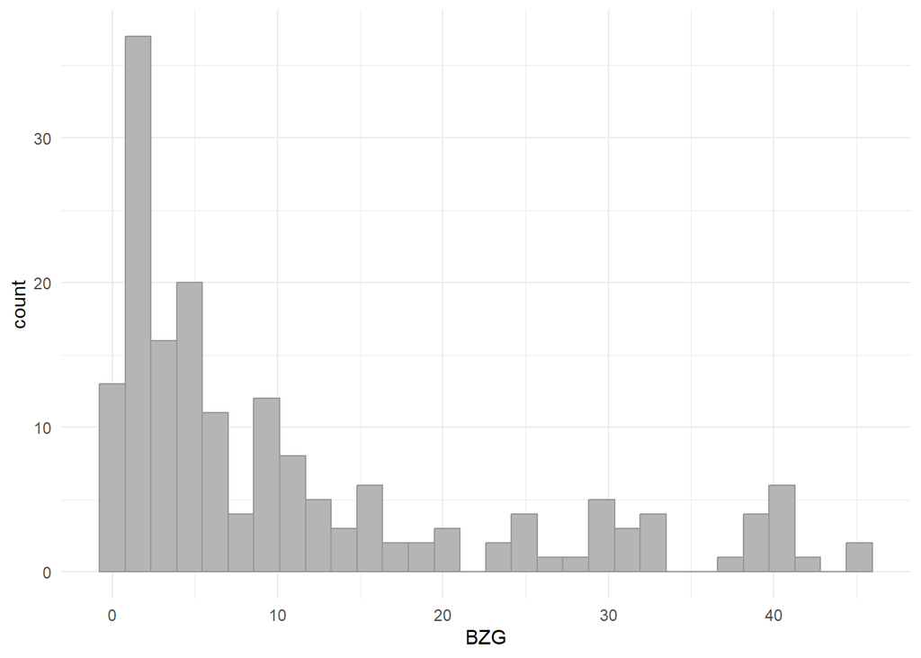

```r
raw4_6 %>%
  ggplot()+
  aes(x=BZG)+
  geom_histogram(fill = "grey71",
                 color = "gray60")+
  theme_minimal()
```

# 6. Verteilungen der Soziodemografika

## Geschlecht

```r
raw4_6 %>%
  count(Geschlecht) %>%
  mutate(prob = n/sum(n)) %>%
  round(2)
```

```
## # A tibble: 2 × 3
##   Geschlecht     n  prob
##        <dbl> <dbl> <dbl>
## 1          1    54  0.31
## 2          2   122  0.69
```

> 1 = männlich 2 = weiblich

## Alter

```r
raw4_6 %>%
  summarise(mean(Alter, na.rm=TRUE),
            median(Alter, na.rm=TRUE),
         sd(Alter, na.rm=TRUE),
         max(Alter, na.rm =TRUE),
         min(Alter, na.rm=TRUE))
```

```
## # A tibble: 1 × 5
##   `mean(Alter, na.rm = TRUE)` median(Alter, na.rm = TRU…¹ sd(Alter, na.rm = TR…²
##                         <dbl>                       <dbl>                  <dbl>
## 1                        40.3                          36                   13.4
## # ℹ abbreviated names: ¹`median(Alter, na.rm = TRUE)`,
## #   ²`sd(Alter, na.rm = TRUE)`
## # ℹ 2 more variables: `max(Alter, na.rm = TRUE)` <dbl>,
## #   `min(Alter, na.rm = TRUE)` <dbl>
```

```r
raw4_6 %>%
  filter(Alter > 60)
```

```
## # A tibble: 6 × 73
##      ID Alter Geschlecht Bildung Bildung_sonstig   BZG Beschaeftigungsart
##   <int> <dbl>      <dbl>   <dbl> <chr>           <dbl>              <dbl>
## 1     8    63          1       6 <NA>             41.5                  2
## 2    14    61          2       3 <NA>             23.2                  2
## 3    15    62          1       5 <NA>             44.5                  2
## 4    43    62          1       3 <NA>             45.7                  2
## 5   148    62          2       7 <NA>             15.7                  2
## 6   168    61          2       6 <NA>             11.3                  2
## # ℹ 66 more variables: Arbeitszeitmodell <dbl>, Gehalt <dbl>,
## #   Position_im_Unternehmen <dbl>, Remotarbeit <dbl>, IS_K01 <dbl>,
## #   IS_K02 <dbl>, IS_K03 <dbl>, IS_K04 <dbl>, IS_E05 <dbl>, IS_E06 <dbl>,
## #   IS_E07 <dbl>, IS_E08 <dbl>, OC_A01 <dbl>, OC_A02 <dbl>, OC_A03 <dbl>,
## #   OC_A04 <dbl>, OC_A05 <dbl>, CPE_C01 <dbl>, CPE_C02 <dbl>, CPE_C03 <dbl>,
## #   CPE_C04 <dbl>, CPE_I05 <dbl>, CPE_I06 <dbl>, CPE_I07 <dbl>, CPE_I08 <dbl>,
## #   CPE_M09 <dbl>, CPE_M10 <dbl>, CPE_M11 <dbl>, CPE_M12 <dbl>, …
```

### visuelle Darstellung des Alters

```r
mean_value_Alter <- mean(raw4_6$Alter, na.rm=TRUE)
median_value_Alter <- median(raw4_6$Alter, na.rm=TRUE)
sd_value_Alter <- sd(raw4_6$Alter, na.rm=TRUE)
```

```r
raw4_6 %>%
  filter(is.na(Alter))
```

```
## # A tibble: 2 × 73
##      ID Alter Geschlecht Bildung Bildung_sonstig   BZG Beschaeftigungsart
##   <int> <dbl>      <dbl>   <dbl> <chr>           <dbl>              <dbl>
## 1   131    NA          2       7 <NA>               11                  2
## 2   142    NA          2       7 <NA>                7                  2
## # ℹ 66 more variables: Arbeitszeitmodell <dbl>, Gehalt <dbl>,
## #   Position_im_Unternehmen <dbl>, Remotarbeit <dbl>, IS_K01 <dbl>,
## #   IS_K02 <dbl>, IS_K03 <dbl>, IS_K04 <dbl>, IS_E05 <dbl>, IS_E06 <dbl>,
## #   IS_E07 <dbl>, IS_E08 <dbl>, OC_A01 <dbl>, OC_A02 <dbl>, OC_A03 <dbl>,
## #   OC_A04 <dbl>, OC_A05 <dbl>, CPE_C01 <dbl>, CPE_C02 <dbl>, CPE_C03 <dbl>,
## #   CPE_C04 <dbl>, CPE_I05 <dbl>, CPE_I06 <dbl>, CPE_I07 <dbl>, CPE_I08 <dbl>,
## #   CPE_M09 <dbl>, CPE_M10 <dbl>, CPE_M11 <dbl>, CPE_M12 <dbl>, …
```

```r
raw4_6a <- raw4_6 %>%
  drop_na(Alter)
raw4_6a
```

```
## # A tibble: 174 × 73
##       ID Alter Geschlecht Bildung Bildung_sonstig    BZG Beschaeftigungsart
##    <int> <dbl>      <dbl>   <dbl> <chr>            <dbl>              <dbl>
##  1     1    57          1       7 <NA>             0.833                  2
##  2     2    52          2       6 <NA>            26.7                    2
##  3     3    25          2       6 <NA>             2.25                   1
##  4     4    27          1       5 <NA>             4                      2
##  5     5    30          1       7 <NA>             6.75                   2
##  6     6    46          1       5 <NA>            15.9                    2
##  7     7    27          1       5 <NA>             6.75                   2
##  8     8    63          1       6 <NA>            41.5                    2
##  9     9    27          1       9 2. Staatsexamen  4                      2
## 10    10    26          1       4 <NA>             1.08                   1
## # ℹ 164 more rows
## # ℹ 66 more variables: Arbeitszeitmodell <dbl>, Gehalt <dbl>,
## #   Position_im_Unternehmen <dbl>, Remotarbeit <dbl>, IS_K01 <dbl>,
## #   IS_K02 <dbl>, IS_K03 <dbl>, IS_K04 <dbl>, IS_E05 <dbl>, IS_E06 <dbl>,
## #   IS_E07 <dbl>, IS_E08 <dbl>, OC_A01 <dbl>, OC_A02 <dbl>, OC_A03 <dbl>,
## #   OC_A04 <dbl>, OC_A05 <dbl>, CPE_C01 <dbl>, CPE_C02 <dbl>, CPE_C03 <dbl>,
## #   CPE_C04 <dbl>, CPE_I05 <dbl>, CPE_I06 <dbl>, CPE_I07 <dbl>, …
```

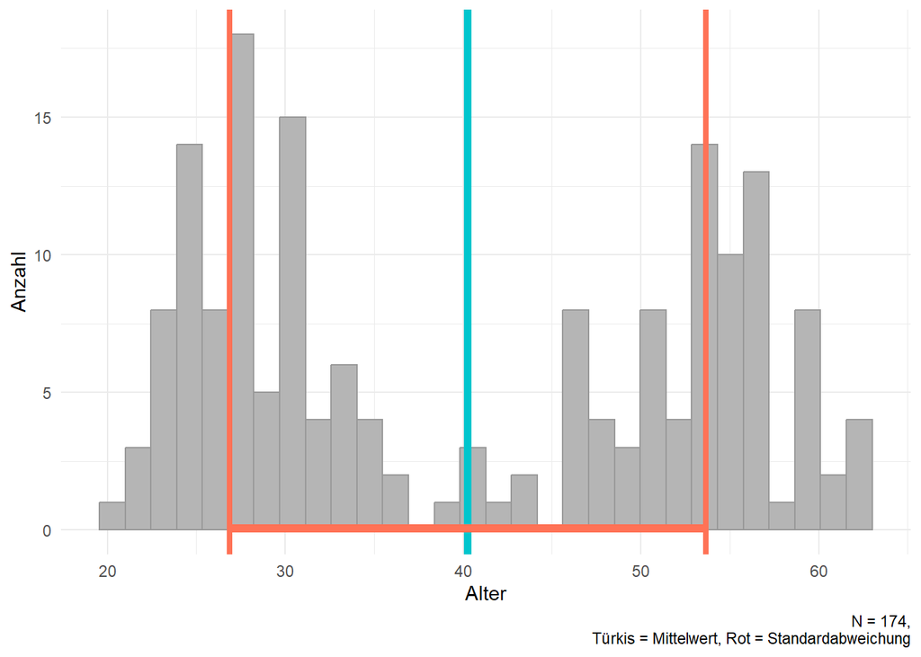

```r
plot_alter <- raw4_6a %>%
  ggplot()+
  aes(x=Alter)+
  geom_histogram(fill = "grey71",
                 color = "gray60")+
  geom_vline(xintercept=mean_value_Alter , color="turquoise3", size=2)+
  geom_vline(xintercept=mean_value_Alter+sd_value_Alter, color="coral1", size=1.5)+
  geom_vline(xintercept=mean_value_Alter-sd_value_Alter, color="coral1", size=1.5)+
  geom_rect(xmin = mean_value_Alter - sd_value_Alter,
            xmax=mean_value_Alter+sd_value_Alter,
            ymin=-.1, ymax=0.2, fill="coral1")+
  ylab("Anzahl")+
  labs(caption = "N = 174,
                  Türkis = Mittelwert, Rot = Standardabweichung")+
  theme_minimal()
plot_alter
```

```r
ggsave(filename = "Altersverteilung.png", plot = plot_alter, width = 8, height = 6, dpi = 300)
```

## Bildung

```r
raw4_6 %>%
  count(Bildung) %>%
  mutate(prob = n/sum(n)) %>%
  round(2)
```

```
## # A tibble: 8 × 3
##   Bildung     n  prob
##     <dbl> <dbl> <dbl>
## 1       2     7  0.04
## 2       3    20  0.11
## 3       4    19  0.11
## 4       5    32  0.18
## 5       6    53  0.3
## 6       7    41  0.23
## 7       8     2  0.01
## 8       9     2  0.01
```

### Visuelle Darstellung der Bildung

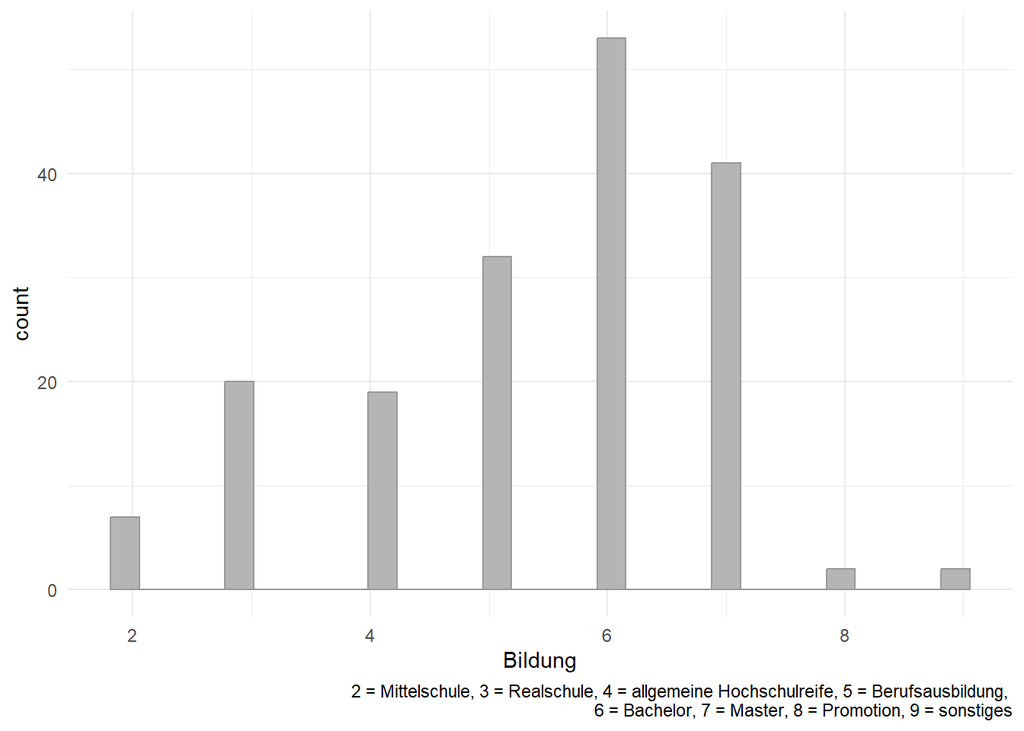

```r
raw4_6 %>%
  ggplot()+
  aes(x=Bildung)+
  geom_histogram(fill = "grey71",
                 color = "gray60")+
  labs(caption = "2 = Mittelschule, 3 = Realschule, 4 = allgemeine Hochschulreife, 5 = Berufsausbildung,
                  6 = Bachelor, 7 = Master, 8 = Promotion, 9 = sonstiges")+
  theme_minimal()
```

## Beschäftigungsart

```r
raw4_6 %>%
  count(Beschaeftigungsart) %>%
    mutate(prob = n/sum(n)) %>%
  round(2)
```

```
## # A tibble: 2 × 3
##   Beschaeftigungsart     n  prob
##                <dbl> <dbl> <dbl>
## 1                  1    20  0.11
## 2                  2   156  0.89
```

> 1 = befristet, 2 = unbefristet

## Arbeitszeitmodell = Stunden/Woche

```r
raw4_6 %>%
  summarise(mean = mean(Arbeitszeitmodell, na.rm=TRUE),
            median = median(Arbeitszeitmodell, na.rm=TRUE),
         sd = sd(Arbeitszeitmodell, na.rm=TRUE),
         min = min(Arbeitszeitmodell, na.rm=TRUE),
         max = max(Arbeitszeitmodell, na.rm=TRUE))
```

```
## # A tibble: 1 × 5
##    mean median    sd   min   max
##   <dbl>  <dbl> <dbl> <dbl> <dbl>
## 1  31.6     35  9.86     0    56
```

### Visuelle Darstellung der verschiedenen Arbeitsmodelle

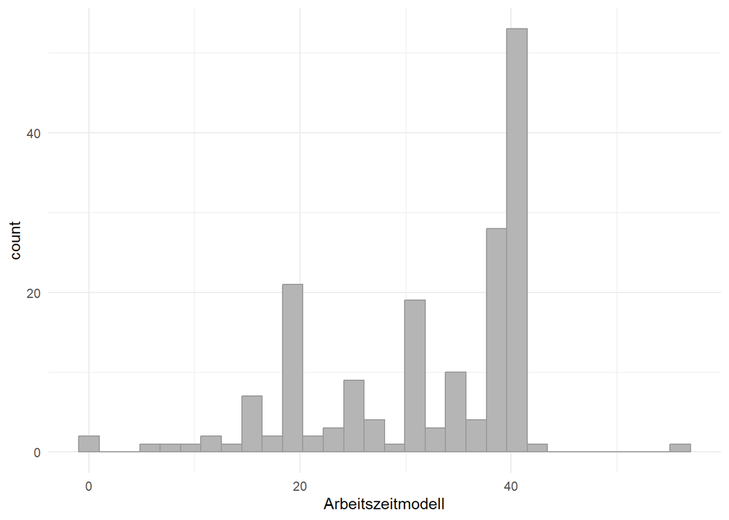

```r
raw4_6 %>%
  ggplot()+
  aes(x=Arbeitszeitmodell)+
  geom_histogram(fill = "grey71",
                 color = "gray60")+
  theme_minimal()
```

### Arbeitszeitmodell Extremwerte betrachten

```r
raw4_6 %>%
  filter(Arbeitszeitmodell < 10 | Arbeitszeitmodell > 45) %>%
  arrange(desc(Arbeitszeitmodell)) %>%
  select(ID, Alter, Geschlecht, Bildung, Arbeitszeitmodell, everything())
```

```
## # A tibble: 6 × 73
##      ID Alter Geschlecht Bildung Arbeitszeitmodell Bildung_sonstig    BZG
##   <int> <dbl>      <dbl>   <dbl>             <dbl> <chr>            <dbl>
## 1    93    29          1       5              56   <NA>             2.67
## 2    47    24          1       6               9   <NA>             5
## 3    57    23          1       6               7.5 <NA>             0.583
## 4    66    23          1       4               5   <NA>             0.583
## 5   124    46          1       7               0   <NA>             3.75
## 6   155    59          2       6               0   <NA>            39.8
## # ℹ 66 more variables: Beschaeftigungsart <dbl>, Gehalt <dbl>,
## #   Position_im_Unternehmen <dbl>, Remotarbeit <dbl>, IS_K01 <dbl>,
## #   IS_K02 <dbl>, IS_K03 <dbl>, IS_K04 <dbl>, IS_E05 <dbl>, IS_E06 <dbl>,
## #   IS_E07 <dbl>, IS_E08 <dbl>, OC_A01 <dbl>, OC_A02 <dbl>, OC_A03 <dbl>,
## #   OC_A04 <dbl>, OC_A05 <dbl>, CPE_C01 <dbl>, CPE_C02 <dbl>, CPE_C03 <dbl>,
## #   CPE_C04 <dbl>, CPE_I05 <dbl>, CPE_I06 <dbl>, CPE_I07 <dbl>, CPE_I08 <dbl>,
## #   CPE_M09 <dbl>, CPE_M10 <dbl>, CPE_M11 <dbl>, CPE_M12 <dbl>, …
```

## Gehalt

```r
raw4_6 %>%
  count(Gehalt) %>%
  mutate(prob = n/sum(n)) %>%
  round(2)
```

```
## # A tibble: 8 × 3
##   Gehalt     n  prob
##    <dbl> <dbl> <dbl>
## 1      1    14  0.08
## 2      2    54  0.31
## 3      3    56  0.32
## 4      4    27  0.15
## 5      5     7  0.04
## 6      6     6  0.03
## 7      7    10  0.06
## 8     NA     2  0.01
```

### Visuelle Darstellung des Gehalts

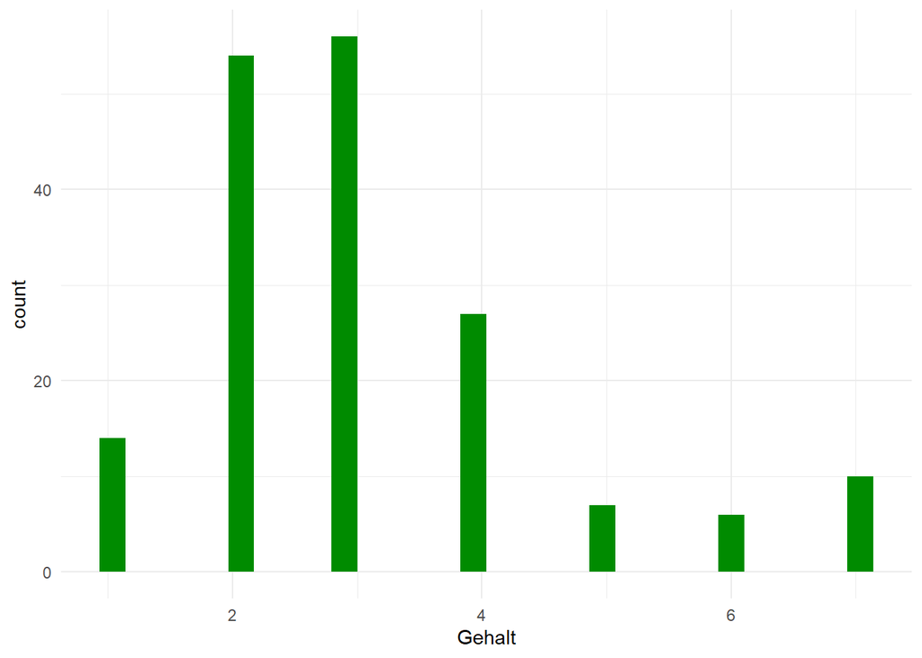

```r
raw4_6 %>%
  ggplot()+
  aes(x=Gehalt)+
  geom_histogram(fill = "green4")+
  theme_minimal()
```

> Nach Absprache mit Frau Sende werden die Gehaltsstufen 5-7 in einer Stufe zusammengefasst!

#### Gehaltsstufen 5-7 zusammenfassen

```r
raw4_7 <- raw4_6 %>%
  mutate(Gehalt_n = case_when(
    Gehalt == 1 ~ 1,
    Gehalt == 2 ~ 2,
    Gehalt == 3 ~ 3,
    Gehalt == 4 ~ 4,
    Gehalt == 5 ~ 5,
    Gehalt == 6 ~ 5,
    Gehalt == 7 ~ 5))
```

```r
raw4_7 %>%
  select(Gehalt, Gehalt_n) %>%
  count(Gehalt, Gehalt_n)
```

```
## # A tibble: 8 × 3
##   Gehalt Gehalt_n     n
##    <dbl>    <dbl> <int>
## 1      1        1    14
## 2      2        2    54
## 3      3        3    56
## 4      4        4    27
## 5      5        5     7
## 6      6        5     6
## 7      7        5    10
## 8     NA       NA     2
```

```r
raw4_8 <- raw4_7 %>%
  select(-Gehalt) %>%
  select(ID, Alter, Geschlecht, Bildung, Bildung_sonstig, BZG, Beschaeftigungsart, Arbeitszeitmodell, Gehalt_n, Position_im_Unternehmen, Remotarbeit, everything())
```

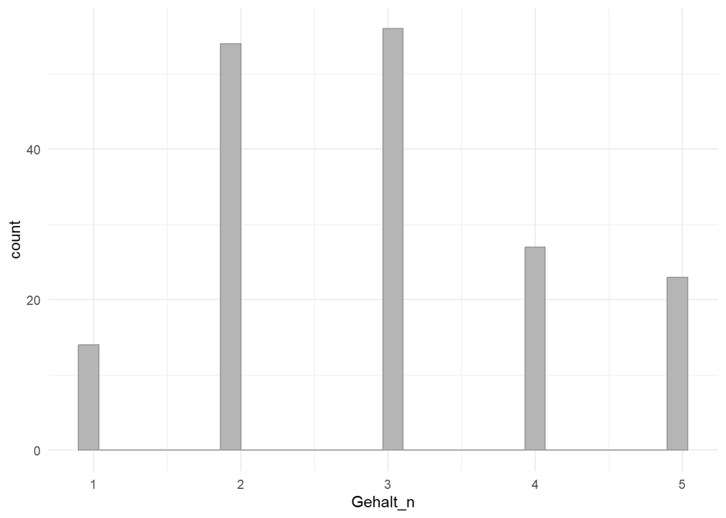

```r
raw4_8 %>%
  ggplot()+
  aes(x=Gehalt_n)+
  geom_histogram(fill = "grey71",
                 color = "gray60")+
  theme_minimal()
```

```r
raw4_8 %>%
  count(Gehalt_n) %>%
  mutate(prob = n/sum(n)) %>%
  round(2)
```

```
## # A tibble: 6 × 3
##   Gehalt_n     n  prob
##      <dbl> <dbl> <dbl>
## 1        1    14  0.08
## 2        2    54  0.31
## 3        3    56  0.32
## 4        4    27  0.15
## 5        5    23  0.13
## 6       NA     2  0.01
```

## Position im Unternehmen

```r
raw4_8 %>%
  count(Position_im_Unternehmen) %>%
  mutate(prob = n/sum(n)) %>%
  round(2)
```

```
## # A tibble: 4 × 3
##   Position_im_Unternehmen     n  prob
##                     <dbl> <dbl> <dbl>
## 1                       1   139  0.79
## 2                       2    20  0.11
## 3                       3    12  0.07
## 4                       4     5  0.03
```

```r
raw4_8a <- raw4_8 %>%
  mutate(Position_im_Unternehmen = case_when(
    Position_im_Unternehmen == 1 ~ 0,
    Position_im_Unternehmen == 2 ~ 1,
    Position_im_Unternehmen == 3 ~ 1,
    Position_im_Unternehmen == 4 ~ 1))
```

> 0 = keine Führungsposition 1 = Führungsposition Wie mit Frau Sende besprochen, wird diese Variable als dichotome Variable umformatiert.

```r
raw4_8a %>%
  count(Position_im_Unternehmen) %>%
  mutate(prob = n/sum(n)) %>%
  round(2)
```

```
## # A tibble: 2 × 3
##   Position_im_Unternehmen     n  prob
##                     <dbl> <dbl> <dbl>
## 1                       0   139  0.79
## 2                       1    37  0.21
```

### Visuelle Darstellung der Position im Unternehmen

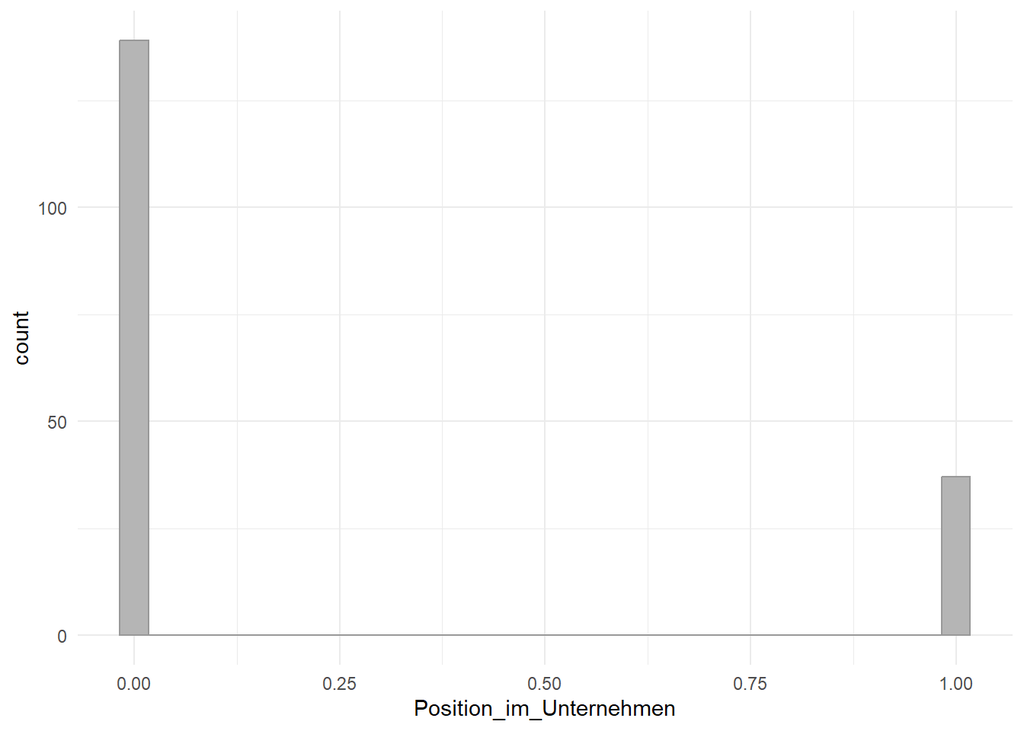

```r
raw4_8a %>%
  ggplot()+
  aes(x=Position_im_Unternehmen)+
  geom_histogram(fill = "grey71",
                 color = "gray60")+
  theme_minimal()
```

## Remotearbeit

```r
raw4_8a %>%
  count(Remotarbeit) %>%
  mutate(prob = n/sum(n)) %>%
  round(2)
```

```
## # A tibble: 6 × 3
##   Remotarbeit     n  prob
##         <dbl> <dbl> <dbl>
## 1           1    85  0.48
## 2           2    26  0.15
## 3           3    26  0.15
## 4           4    22  0.12
## 5           5     9  0.05
## 6           6     8  0.05
```

### Visuelle Darstellung der Remotearbeit

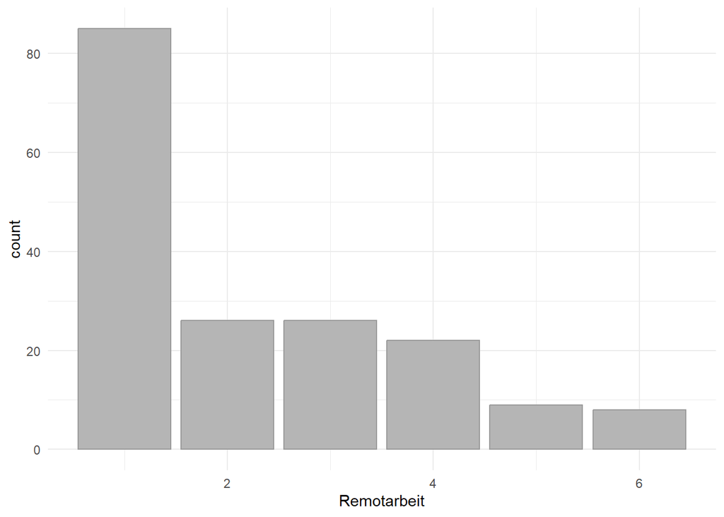

```r
raw4_8a %>%
  ggplot()+
  aes(x=Remotarbeit)+
  geom_bar(fill = "grey71",
                 color = "gray60")+
  theme_minimal()
```

# 7. Datensatz `raw_8` zwischenspeichern

```r
write.csv(raw4_8a, file="raw4.csv")
```

# 8. Cronbachs Alpha berechnen

## Irritation

```r
psych::alpha(subset(raw4_8a, select=c(IS_K01:IS_E08)), check.keys=TRUE)
```

```
##
## Reliability analysis
## Call: psych::alpha(x = subset(raw4_8a, select = c(IS_K01:IS_E08)),
##     check.keys = TRUE)
##
##   raw_alpha std.alpha G6(smc) average_r S/N   ase mean  sd median_r
##       0.86      0.86    0.89      0.44 6.3 0.016  3.2 1.2     0.42
##
##     95% confidence boundaries
##          lower alpha upper
## Feldt     0.83  0.86  0.89
## Duhachek  0.83  0.86  0.89
##
##  Reliability if an item is dropped:
##        raw_alpha std.alpha G6(smc) average_r S/N alpha se var.r med.r
## IS_K01      0.83      0.84    0.86      0.42 5.1    0.020 0.026  0.41
## IS_K02      0.84      0.85    0.87      0.44 5.6    0.018 0.021  0.43
## IS_K03      0.85      0.85    0.88      0.46 5.9    0.017 0.028  0.43
## IS_K04      0.85      0.85    0.87      0.44 5.6    0.018 0.023  0.43
## IS_E05      0.85      0.85    0.88      0.44 5.5    0.018 0.037  0.40
## IS_E06      0.85      0.85    0.88      0.44 5.5    0.018 0.033  0.41
## IS_E07      0.85      0.85    0.87      0.45 5.8    0.017 0.028  0.44
## IS_E08      0.84      0.84    0.87      0.42 5.1    0.020 0.035  0.37
##
##  Item statistics
##          n raw.r std.r r.cor r.drop mean  sd
## IS_K01 176  0.80  0.79  0.77   0.72  3.5 1.8
## IS_K02 176  0.72  0.70  0.68   0.61  4.2 1.8
## IS_K03 176  0.63  0.66  0.60   0.53  2.7 1.5
## IS_K04 176  0.72  0.70  0.67   0.61  3.4 2.0
## IS_E05 176  0.71  0.72  0.66   0.60  2.7 1.7
## IS_E06 176  0.69  0.71  0.66   0.59  3.1 1.7
## IS_E07 176  0.65  0.67  0.62   0.53  3.4 1.7
## IS_E08 176  0.77  0.78  0.73   0.70  2.6 1.6
##
## Non missing response frequency for each item
##           1    2    3    4    5    6    7 miss
## IS_K01 0.15 0.23 0.20 0.10 0.15 0.10 0.07    0
## IS_K02 0.06 0.18 0.15 0.09 0.25 0.18 0.10    0
## IS_K03 0.22 0.34 0.23 0.08 0.10 0.02 0.03    0
## IS_K04 0.19 0.22 0.16 0.06 0.15 0.13 0.07    0
## IS_E05 0.34 0.23 0.14 0.09 0.11 0.06 0.02    0
## IS_E06 0.19 0.25 0.18 0.12 0.18 0.04 0.03    0
## IS_E07 0.15 0.24 0.18 0.11 0.22 0.07 0.03    0
## IS_E08 0.32 0.22 0.22 0.09 0.10 0.03 0.02    0
```

## CPE

```r
psych::alpha(subset(raw4_8a, select=c(CPE_C01:CPE_E16)), check.keys=TRUE)
```

```
##
## Reliability analysis
## Call: psych::alpha(x = subset(raw4_8a, select = c(CPE_C01:CPE_E16)),
##     check.keys = TRUE)
##
##   raw_alpha std.alpha G6(smc) average_r S/N    ase mean  sd median_r
##       0.95      0.95    0.96      0.55  20 0.0053  4.8 1.1     0.57
##
##     95% confidence boundaries
##          lower alpha upper
## Feldt     0.94  0.95  0.96
## Duhachek  0.94  0.95  0.96
##
##  Reliability if an item is dropped:
##         raw_alpha std.alpha G6(smc) average_r S/N alpha se  var.r med.r
## CPE_C01      0.95      0.95    0.96      0.54  18   0.0058 0.0139  0.57
## CPE_C02      0.95      0.95    0.96      0.56  19   0.0055 0.0131  0.57
## CPE_C03      0.95      0.95    0.96      0.54  18   0.0058 0.0140  0.57
## CPE_C04      0.95      0.95    0.96      0.54  18   0.0058 0.0134  0.57
## CPE_I05      0.95      0.95    0.96      0.54  18   0.0058 0.0140  0.57
## CPE_I06      0.95      0.95    0.96      0.55  18   0.0057 0.0143  0.57
## CPE_I07      0.95      0.95    0.96      0.58  21   0.0051 0.0049  0.58
## CPE_I08      0.95      0.95    0.96      0.55  18   0.0056 0.0144  0.57
## CPE_M09      0.95      0.95    0.96      0.55  18   0.0057 0.0135  0.57
## CPE_M10      0.95      0.95    0.96      0.55  18   0.0057 0.0134  0.57
## CPE_M11      0.95      0.95    0.96      0.55  18   0.0057 0.0138  0.57
## CPE_M12      0.95      0.95    0.96      0.55  18   0.0057 0.0141  0.57
## CPE_E13      0.95      0.95    0.95      0.54  18   0.0059 0.0131  0.56
## CPE_E14      0.95      0.95    0.96      0.55  18   0.0058 0.0133  0.57
## CPE_E15      0.95      0.95    0.96      0.55  18   0.0057 0.0140  0.57
## CPE_E16      0.95      0.95    0.96      0.56  19   0.0055 0.0135  0.57
##
##  Item statistics
##           n raw.r std.r r.cor r.drop mean  sd
## CPE_C01 176  0.82  0.81  0.80   0.78  4.9 1.5
## CPE_C02 176  0.71  0.70  0.68   0.66  4.9 1.6
## CPE_C03 176  0.80  0.80  0.79   0.77  5.1 1.5
## CPE_C04 176  0.81  0.80  0.79   0.77  4.7 1.5
## CPE_I05 176  0.81  0.82  0.81   0.78  5.1 1.4
## CPE_I06 176  0.78  0.78  0.77   0.75  4.8 1.4
```

[output cut: 14 more lines]

```
## CPE_C02 0.04 0.06 0.11 0.13 0.26 0.25 0.15 0.00
## CPE_C03 0.03 0.02 0.09 0.18 0.24 0.27 0.16 0.00
## CPE_C04 0.04 0.05 0.14 0.14 0.29 0.26 0.09 0.00
## CPE_I05 0.02 0.02 0.10 0.22 0.19 0.31 0.15 0.00
## CPE_I06 0.03 0.03 0.12 0.20 0.27 0.26 0.09 0.00
## CPE_I07 0.01 0.03 0.06 0.16 0.20 0.32 0.21 0.00
## CPE_I08 0.02 0.06 0.15 0.17 0.22 0.27 0.11 0.00
## CPE_M09 0.08 0.07 0.18 0.21 0.22 0.19 0.05 0.00
## CPE_M10 0.05 0.06 0.10 0.17 0.27 0.25 0.10 0.00
## CPE_M11 0.02 0.03 0.16 0.21 0.31 0.21 0.07 0.01
## CPE_M12 0.02 0.03 0.08 0.16 0.25 0.31 0.16 0.00
## CPE_E13 0.05 0.05 0.15 0.18 0.27 0.18 0.13 0.00
## CPE_E14 0.03 0.03 0.12 0.16 0.25 0.28 0.12 0.00
## CPE_E15 0.02 0.05 0.11 0.15 0.27 0.30 0.11 0.00
## CPE_E16 0.05 0.06 0.10 0.15 0.27 0.25 0.12 0.00
```

## PS

```r
psych::alpha(subset(raw4_8a, select=c(PS_01:PS_07)), check.keys=TRUE)
```

```
##
## Reliability analysis
## Call: psych::alpha(x = subset(raw4_8a, select = c(PS_01:PS_07)), check.keys = TRUE)
##
##   raw_alpha std.alpha G6(smc) average_r S/N   ase mean  sd median_r
##       0.88      0.88    0.87      0.52 7.5 0.014  5.4 1.2     0.53
##
##     95% confidence boundaries
##          lower alpha upper
## Feldt     0.85  0.88  0.90
## Duhachek  0.85  0.88  0.91
##
##  Reliability if an item is dropped:
##       raw_alpha std.alpha G6(smc) average_r S/N alpha se  var.r med.r
## PS_01      0.85      0.85    0.84      0.49 5.9    0.017 0.0055  0.49
## PS_02      0.88      0.88    0.86      0.55 7.2    0.014 0.0030  0.56
## PS_03      0.85      0.86    0.84      0.50 6.0    0.017 0.0060  0.51
## PS_04      0.86      0.86    0.85      0.51 6.3    0.016 0.0058  0.53
## PS_05      0.87      0.87    0.85      0.52 6.6    0.016 0.0043  0.53
## PS_06      0.87      0.87    0.86      0.53 6.7    0.016 0.0057  0.56
## PS_07      0.86      0.87    0.85      0.52 6.4    0.016 0.0065  0.53
##
##  Item statistics
##         n raw.r std.r r.cor r.drop mean  sd
## PS_01 176  0.82  0.83  0.80   0.76  5.5 1.4
## PS_02 176  0.70  0.69  0.61   0.56  5.9 1.7
## PS_03 176  0.82  0.81  0.78   0.73  5.4 1.7
## PS_04 176  0.77  0.78  0.74   0.69  4.9 1.5
## PS_05 176  0.76  0.75  0.70   0.65  5.2 1.7
## PS_06 176  0.73  0.73  0.67   0.63  5.9 1.5
## PS_07 176  0.76  0.77  0.71   0.67  5.5 1.4
##
## Non missing response frequency for each item
##          1    2    3    4    5    6    7 miss
## PS_01 0.02 0.02 0.10 0.03 0.16 0.45 0.20    0
## PS_02 0.05 0.02 0.07 0.05 0.04 0.20 0.57    0
## PS_03 0.03 0.05 0.09 0.07 0.20 0.23 0.34    0
## PS_04 0.03 0.02 0.11 0.20 0.22 0.29 0.11    0
## PS_05 0.03 0.06 0.15 0.06 0.15 0.30 0.26    0
## PS_06 0.02 0.03 0.06 0.01 0.16 0.27 0.45    0
## PS_07 0.02 0.03 0.06 0.10 0.16 0.41 0.22    0
```

## OCA

```r
psych::alpha(subset(raw4_8a, select=c(OC_A01:OC_A05)), check.keys=TRUE)
```

```
##
## Reliability analysis
## Call: psych::alpha(x = subset(raw4_8a, select = c(OC_A01:OC_A05)),
##     check.keys = TRUE)
##
##   raw_alpha std.alpha G6(smc) average_r S/N   ase mean   sd median_r
##       0.91      0.91     0.9      0.67  10 0.011  3.6 0.97     0.65
##
##     95% confidence boundaries
##          lower alpha upper
## Feldt     0.88  0.91  0.93
## Duhachek  0.89  0.91  0.93
##
##  Reliability if an item is dropped:
##        raw_alpha std.alpha G6(smc) average_r S/N alpha se  var.r med.r
## OC_A01      0.90      0.90    0.88      0.70 9.1    0.012 0.0077  0.70
## OC_A02      0.90      0.90    0.88      0.68 8.6    0.013 0.0064  0.65
## OC_A03      0.87      0.87    0.84      0.63 6.7    0.016 0.0034  0.63
## OC_A04      0.87      0.88    0.85      0.64 7.0    0.016 0.0038  0.64
## OC_A05      0.90      0.90    0.88      0.69 8.8    0.013 0.0090  0.69
##
##  Item statistics
##          n raw.r std.r r.cor r.drop mean  sd
## OC_A01 176  0.81  0.81  0.74   0.70  3.6 1.1
## OC_A02 176  0.84  0.83  0.77   0.73  3.4 1.2
## OC_A03 176  0.91  0.91  0.90   0.85  3.6 1.1
## OC_A04 176  0.90  0.90  0.88   0.83  3.5 1.1
## OC_A05 176  0.81  0.82  0.76   0.72  3.6 1.0
##
## Non missing response frequency for each item
##           1    2    3    4    5 miss
## OC_A01 0.07 0.07 0.27 0.33 0.26    0
## OC_A02 0.08 0.20 0.13 0.38 0.21    0
## OC_A03 0.05 0.11 0.24 0.38 0.22    0
## OC_A04 0.07 0.12 0.20 0.41 0.19    0
## OC_A05 0.05 0.09 0.24 0.47 0.15    0
```

## QQ

### QQ-Anand

```r
psych::alpha(subset(raw4_8a, select=c(QQ_01:QQ_07), check.keys=TRUE))
```

```
##
## Reliability analysis
## Call: psych::alpha(x = subset(raw4_8a, select = c(QQ_01:QQ_07), check.keys = TRUE))
##
##   raw_alpha std.alpha G6(smc) average_r S/N   ase mean   sd median_r
##       0.76      0.77    0.78      0.33 3.4 0.028  2.3 0.73     0.33
##
##     95% confidence boundaries
##          lower alpha upper
## Feldt      0.7  0.76  0.81
## Duhachek   0.7  0.76  0.81
##
##  Reliability if an item is dropped:
##       raw_alpha std.alpha G6(smc) average_r S/N alpha se var.r med.r
## QQ_01      0.75      0.76    0.76      0.35 3.2    0.029 0.018  0.35
## QQ_02      0.72      0.73    0.72      0.32 2.8    0.032 0.012  0.32
## QQ_03      0.71      0.73    0.73      0.31 2.7    0.034 0.022  0.29
## QQ_04      0.71      0.72    0.72      0.30 2.6    0.034 0.018  0.32
## QQ_05      0.75      0.77    0.77      0.36 3.3    0.029 0.019  0.37
## QQ_06      0.70      0.71    0.72      0.29 2.5    0.035 0.017  0.29
## QQ_07      0.75      0.77    0.75      0.35 3.3    0.030 0.016  0.36
##
##  Item statistics
##         n raw.r std.r r.cor r.drop mean   sd
## QQ_01 176  0.60  0.57  0.46   0.38  2.6 1.38
## QQ_02 176  0.64  0.68  0.64   0.53  1.5 0.83
## QQ_03 176  0.71  0.70  0.64   0.56  2.6 1.19
## QQ_04 176  0.71  0.73  0.68   0.58  2.1 1.03
## QQ_05 176  0.56  0.55  0.42   0.36  2.4 1.19
## QQ_06 176  0.74  0.75  0.72   0.61  2.1 1.09
## QQ_07 176  0.58  0.56  0.46   0.39  2.5 1.22
##
## Non missing response frequency for each item
##          1    2    3    4    5 miss
## QQ_01 0.26 0.27 0.15 0.18 0.13    0
## QQ_02 0.65 0.28 0.02 0.03 0.02    0
## QQ_03 0.18 0.41 0.16 0.18 0.07    0
## QQ_04 0.29 0.44 0.16 0.08 0.03    0
## QQ_05 0.26 0.36 0.22 0.09 0.08    0
## QQ_06 0.33 0.41 0.12 0.10 0.04    0
## QQ_07 0.22 0.36 0.20 0.13 0.09    0
```

### QQ-Neu

```r
psych::alpha(subset(raw4_8a, select=c(QQ_N08:QQ_N14), check.keys=TRUE))
```

```
##
## Reliability analysis
## Call: psych::alpha(x = subset(raw4_8a, select = c(QQ_N08:QQ_N14), check.keys = TRUE))
##
##   raw_alpha std.alpha G6(smc) average_r S/N   ase mean   sd median_r
##       0.75      0.76    0.75      0.31 3.1 0.028  2.2 0.67     0.35
##
##     95% confidence boundaries
##          lower alpha upper
## Feldt     0.69  0.75  0.80
## Duhachek  0.70  0.75  0.81
##
##  Reliability if an item is dropped:
##        raw_alpha std.alpha G6(smc) average_r S/N alpha se  var.r med.r
## QQ_N08      0.76      0.76    0.75      0.35 3.2    0.028 0.0064  0.36
## QQ_N09      0.71      0.71    0.70      0.29 2.5    0.034 0.0137  0.31
## QQ_N10      0.71      0.71    0.69      0.29 2.5    0.034 0.0114  0.30
## QQ_N11      0.73      0.73    0.72      0.32 2.8    0.031 0.0111  0.35
## QQ_N12      0.70      0.71    0.70      0.29 2.4    0.035 0.0136  0.31
## QQ_N13      0.71      0.71    0.70      0.29 2.5    0.033 0.0159  0.31
## QQ_N14      0.73      0.73    0.72      0.31 2.7    0.032 0.0146  0.35
##
##  Item statistics
##          n raw.r std.r r.cor r.drop mean   sd
## QQ_N08 176  0.49  0.48  0.34   0.29  2.8 1.07
## QQ_N09 176  0.68  0.68  0.61   0.52  2.1 1.09
## QQ_N10 176  0.69  0.69  0.63   0.54  2.2 1.07
## QQ_N11 176  0.59  0.60  0.51   0.42  2.2 0.97
## QQ_N12 176  0.72  0.69  0.63   0.55  2.1 1.22
## QQ_N13 176  0.66  0.68  0.61   0.53  1.7 0.84
## QQ_N14 176  0.62  0.63  0.53   0.45  2.3 1.04
##
## Non missing response frequency for each item
##           1    2    3    4    5 miss
## QQ_N08 0.13 0.30 0.27 0.27 0.02    0
## QQ_N09 0.37 0.37 0.13 0.10 0.03    0
## QQ_N10 0.24 0.46 0.16 0.09 0.05    0
## QQ_N11 0.22 0.51 0.16 0.07 0.03    0
## QQ_N12 0.39 0.36 0.06 0.12 0.06    0
## QQ_N13 0.46 0.43 0.05 0.06 0.01    0
## QQ_N14 0.18 0.52 0.14 0.11 0.05    0
```

### QQ-Gesamt

```r
psych::alpha(subset(raw4_8a, select=c(QQ_01:QQ_N14), check.keys=TRUE))
```

```
##
## Reliability analysis
## Call: psych::alpha(x = subset(raw4_8a, select = c(QQ_01:QQ_N14), check.keys = TRUE))
##
##   raw_alpha std.alpha G6(smc) average_r S/N   ase mean   sd median_r
##       0.85      0.86    0.88       0.3 5.9 0.017  2.2 0.64      0.3
##
##     95% confidence boundaries
##          lower alpha upper
## Feldt     0.81  0.85  0.88
## Duhachek  0.82  0.85  0.88
##
##  Reliability if an item is dropped:
##        raw_alpha std.alpha G6(smc) average_r S/N alpha se var.r med.r
## QQ_01       0.84      0.85    0.87      0.30 5.7    0.017 0.019  0.31
## QQ_02       0.83      0.84    0.86      0.28 5.1    0.019 0.016  0.29
## QQ_03       0.84      0.84    0.86      0.29 5.4    0.018 0.020  0.30
## QQ_04       0.84      0.84    0.86      0.29 5.4    0.018 0.018  0.31
## QQ_05       0.84      0.85    0.87      0.31 5.7    0.017 0.018  0.32
## QQ_06       0.83      0.83    0.86      0.28 5.0    0.019 0.017  0.28
## QQ_07       0.85      0.86    0.87      0.31 5.9    0.017 0.017  0.34
## QQ_N08      0.85      0.86    0.88      0.32 6.2    0.016 0.014  0.34
## QQ_N09      0.84      0.85    0.87      0.30 5.5    0.018 0.019  0.30
## QQ_N10      0.83      0.84    0.86      0.29 5.3    0.018 0.019  0.29
## QQ_N11      0.84      0.85    0.87      0.30 5.6    0.018 0.019  0.31
## QQ_N12      0.83      0.84    0.86      0.29 5.2    0.019 0.019  0.29
## QQ_N13      0.84      0.84    0.86      0.29 5.3    0.018 0.019  0.29
## QQ_N14      0.84      0.84    0.87      0.30 5.4    0.018 0.020  0.30
##
##  Item statistics
##          n raw.r std.r r.cor r.drop mean   sd
## QQ_01  176  0.55  0.53  0.47   0.43  2.6 1.38
## QQ_02  176  0.70  0.72  0.71   0.65  1.5 0.83
## QQ_03  176  0.63  0.61  0.57   0.53  2.6 1.19
## QQ_04  176  0.61  0.62  0.59   0.53  2.1 1.03
## QQ_05  176  0.52  0.51  0.46   0.41  2.4 1.19
## QQ_06  176  0.75  0.75  0.74   0.69  2.1 1.09
## QQ_07  176  0.46  0.44  0.38   0.34  2.5 1.22
## QQ_N08 176  0.33  0.33  0.26   0.22  2.8 1.07
## QQ_N09 176  0.59  0.60  0.56   0.51  2.1 1.09
## QQ_N10 176  0.65  0.66  0.63   0.58  2.2 1.07
## QQ_N11 176  0.54  0.55  0.51   0.46  2.2 0.97
## QQ_N12 176  0.69  0.68  0.65   0.60  2.1 1.22
## QQ_N13 176  0.62  0.65  0.61   0.56  1.7 0.84
## QQ_N14 176  0.59  0.60  0.56   0.51  2.3 1.04
##
## Non missing response frequency for each item
##           1    2    3    4    5 miss
## QQ_01  0.26 0.27 0.15 0.18 0.13    0
## QQ_02  0.65 0.28 0.02 0.03 0.02    0
## QQ_03  0.18 0.41 0.16 0.18 0.07    0
## QQ_04  0.29 0.44 0.16 0.08 0.03    0
## QQ_05  0.26 0.36 0.22 0.09 0.08    0
## QQ_06  0.33 0.41 0.12 0.10 0.04    0
## QQ_07  0.22 0.36 0.20 0.13 0.09    0
## QQ_N08 0.13 0.30 0.27 0.27 0.02    0
## QQ_N09 0.37 0.37 0.13 0.10 0.03    0
## QQ_N10 0.24 0.46 0.16 0.09 0.05    0
## QQ_N11 0.22 0.51 0.16 0.07 0.03    0
## QQ_N12 0.39 0.36 0.06 0.12 0.06    0
## QQ_N13 0.46 0.43 0.05 0.06 0.01    0
## QQ_N14 0.18 0.52 0.14 0.11 0.05    0
```

> Wie bereits in der oberen Analyse der neuen Fragen gesehen, fällt auch in der Gesamtbetrachtung auf, dass vor allem das Item `QQ_N08` eine Item-Rest-Korrelation von 0.217 hat, weswegen dieses Item aus dem Fragebogen fällt.

### QQ_N08 aus dem Datensatz werfen

```r
raw4_9 <- raw4_8a %>%
  select(-QQ_N08)
```

#### QQ_Gesamt prüfen

```r
psych::alpha(subset(raw4_9, select=c(QQ_01:QQ_N14), check.keys=TRUE))
```

```
##
## Reliability analysis
## Call: psych::alpha(x = subset(raw4_9, select = c(QQ_01:QQ_N14), check.keys = TRUE))
##
##   raw_alpha std.alpha G6(smc) average_r S/N   ase mean   sd median_r
##       0.85      0.86    0.88      0.32 6.2 0.016  2.2 0.66     0.34
##
##     95% confidence boundaries
##          lower alpha upper
## Feldt     0.82  0.85  0.88
## Duhachek  0.82  0.85  0.89
##
##  Reliability if an item is dropped:
##        raw_alpha std.alpha G6(smc) average_r S/N alpha se var.r med.r
## QQ_01       0.85      0.86    0.87      0.33 6.0    0.016 0.014  0.35
## QQ_02       0.84      0.84    0.86      0.31 5.4    0.018 0.012  0.32
## QQ_03       0.84      0.85    0.87      0.32 5.7    0.018 0.016  0.35
## QQ_04       0.84      0.85    0.86      0.32 5.7    0.018 0.015  0.35
## QQ_05       0.85      0.86    0.87      0.33 6.0    0.017 0.015  0.35
## QQ_06       0.83      0.84    0.86      0.31 5.3    0.019 0.013  0.31
## QQ_07       0.86      0.86    0.87      0.34 6.3    0.016 0.011  0.36
## QQ_N09      0.85      0.85    0.87      0.33 5.9    0.017 0.014  0.34
## QQ_N10      0.84      0.85    0.86      0.32 5.6    0.018 0.015  0.33
## QQ_N11      0.85      0.86    0.87      0.33 5.9    0.017 0.014  0.35
## QQ_N12      0.84      0.85    0.87      0.32 5.5    0.018 0.015  0.32
## QQ_N13      0.84      0.85    0.87      0.32 5.7    0.018 0.014  0.32
## QQ_N14      0.84      0.85    0.87      0.32 5.8    0.017 0.015  0.34
##
##  Item statistics
##          n raw.r std.r r.cor r.drop mean   sd
## QQ_01  176  0.55  0.53  0.47   0.43  2.6 1.38
## QQ_02  176  0.70  0.72  0.72   0.65  1.5 0.83
## QQ_03  176  0.63  0.62  0.58   0.54  2.6 1.19
## QQ_04  176  0.63  0.63  0.60   0.55  2.1 1.03
## QQ_05  176  0.55  0.54  0.49   0.44  2.4 1.19
## QQ_06  176  0.75  0.76  0.75   0.69  2.1 1.09
## QQ_07  176  0.46  0.44  0.38   0.34  2.5 1.22
## QQ_N09 176  0.57  0.57  0.53   0.47  2.1 1.09
## QQ_N10 176  0.66  0.67  0.64   0.58  2.2 1.07
## QQ_N11 176  0.55  0.56  0.52   0.46  2.2 0.97
## QQ_N12 176  0.68  0.67  0.64   0.59  2.1 1.22
## QQ_N13 176  0.61  0.64  0.60   0.55  1.7 0.84
## QQ_N14 176  0.60  0.60  0.56   0.51  2.3 1.04
##
## Non missing response frequency for each item
##           1    2    3    4    5 miss
## QQ_01  0.26 0.27 0.15 0.18 0.13    0
## QQ_02  0.65 0.28 0.02 0.03 0.02    0
## QQ_03  0.18 0.41 0.16 0.18 0.07    0
## QQ_04  0.29 0.44 0.16 0.08 0.03    0
## QQ_05  0.26 0.36 0.22 0.09 0.08    0
## QQ_06  0.33 0.41 0.12 0.10 0.04    0
## QQ_07  0.22 0.36 0.20 0.13 0.09    0
## QQ_N09 0.37 0.37 0.13 0.10 0.03    0
## QQ_N10 0.24 0.46 0.16 0.09 0.05    0
## QQ_N11 0.22 0.51 0.16 0.07 0.03    0
## QQ_N12 0.39 0.36 0.06 0.12 0.06    0
## QQ_N13 0.46 0.43 0.05 0.06 0.01    0
## QQ_N14 0.18 0.52 0.14 0.11 0.05    0
```

## SL

```r
psych::alpha(subset(raw4_9, select=c(SL_01:SL_07)), check.keys=TRUE)
```

```
##
## Reliability analysis
## Call: psych::alpha(x = subset(raw4_9, select = c(SL_01:SL_07)), check.keys = TRUE)
##
##   raw_alpha std.alpha G6(smc) average_r S/N   ase mean  sd median_r
##       0.85      0.85    0.84      0.45 5.8 0.017  4.5 1.3     0.44
##
##     95% confidence boundaries
##          lower alpha upper
## Feldt     0.82  0.85  0.88
## Duhachek  0.82  0.85  0.88
##
##  Reliability if an item is dropped:
##       raw_alpha std.alpha G6(smc) average_r S/N alpha se  var.r med.r
## SL_01      0.83      0.83    0.82      0.45 5.0    0.019 0.0083  0.44
## SL_02      0.82      0.82    0.80      0.44 4.6    0.020 0.0042  0.41
## SL_03      0.82      0.83    0.81      0.44 4.7    0.020 0.0063  0.42
## SL_04      0.83      0.84    0.82      0.46 5.2    0.019 0.0074  0.46
## SL_05      0.82      0.82    0.80      0.44 4.6    0.020 0.0044  0.41
## SL_06      0.84      0.84    0.83      0.47 5.3    0.018 0.0080  0.46
## SL_07      0.85      0.85    0.83      0.48 5.6    0.017 0.0064  0.47
##
##  Item statistics
##         n raw.r std.r r.cor r.drop mean  sd
## SL_01 176  0.73  0.73  0.67   0.62  4.6 1.7
## SL_02 176  0.78  0.78  0.75   0.68  3.9 1.8
## SL_03 176  0.79  0.77  0.73   0.67  4.5 2.1
## SL_04 176  0.71  0.71  0.63   0.59  4.1 1.8
## SL_05 175  0.78  0.78  0.75   0.69  3.4 1.6
## SL_06 176  0.66  0.69  0.60   0.56  5.5 1.4
## SL_07 176  0.64  0.65  0.55   0.51  5.3 1.7
##
## Non missing response frequency for each item
##          1    2    3    4    5    6    7 miss
## SL_01 0.07 0.07 0.12 0.09 0.28 0.27 0.10 0.00
## SL_02 0.12 0.12 0.16 0.16 0.26 0.10 0.08 0.00
## SL_03 0.15 0.07 0.11 0.10 0.16 0.17 0.24 0.00
## SL_04 0.11 0.12 0.12 0.21 0.18 0.17 0.09 0.00
## SL_05 0.18 0.10 0.23 0.26 0.11 0.08 0.03 0.01
## SL_06 0.03 0.03 0.06 0.06 0.22 0.38 0.23 0.00
## SL_07 0.05 0.02 0.09 0.14 0.15 0.21 0.34 0.00
```

# 9.Spearman-Brown-Formel zum Berechnen der Reliabilität bei Testverlängerung

```r
library(CTT)
spearman.brown(0.7719431, input = 13/7 ,n.or.r = "n")
```

```
## $r.new
## [1] 0.862754
```

> Aufgrund dessen, dass eine Verlängerung der Anand-Skala eine Reliabilität von 0.862754 vorweisen würde und die Relibilität der von uns verlängerten Skala 0.8614523 beträgt ergibt sich daraus eine Differenz von 0.0013017 Da sich hierdurch nur eine geringe Verbesserung zeigt und dies unverhältnismäßig zur Komplexität der Skala beitragen würde, wird im Folgenden mit der Originalskala gerechnet.

# 10. Skalen zusammenfassen

## Irriation (IS)

```r
d_work <- raw4_9
d_work$IS_mean <- rowMeans(subset(raw4_9, select = c(IS_K01, IS_K02, IS_K03, IS_K04, IS_E05, IS_E06, IS_E07, IS_E08)))
d_work$IS_K_mean <- rowMeans(subset(raw4_9, select = c(IS_K01, IS_K02, IS_K03, IS_K04)))
d_work$IS_E_mean <- rowMeans(subset(raw4_9, select = c(IS_E05, IS_E06, IS_E07, IS_E08)))
```

## Kultur für psychologisches Empowerment in Organisationen (CPE)

```r
d_work$CPE_mean <- rowMeans(subset(raw4_9, select = c(CPE_C01, CPE_C02, CPE_C03, CPE_C04, CPE_I05, CPE_I06, CPE_I07, CPE_I08, CPE_M09, CPE_M10, CPE_M11, CPE_M12, CPE_E13, CPE_E14, CPE_E15, CPE_E16)), na.rm=TRUE)
d_work$CPE_C_mean <- rowMeans(subset(raw4_9, select = c(CPE_C01, CPE_C02, CPE_C03, CPE_C04)))
d_work$CPE_I_mean <- rowMeans(subset(raw4_9, select = c(CPE_I05, CPE_I06, CPE_I07, CPE_I08)))
d_work$CPE_M_mean <- rowMeans(subset(raw4_9, select = c(CPE_M09, CPE_M10, CPE_M11, CPE_M12)), na.rm = TRUE)
d_work$CPE_E_mean <- rowMeans(subset(raw4_9, select = c(CPE_E13, CPE_E14, CPE_E15, CPE_E16)))
```

## Psychologische Sicherheit (PS)

```r
d_work$PS_mean <- rowMeans(subset(raw4_9, select = c(PS_01, PS_02, PS_03, PS_04, PS_05, PS_06, PS_07)))
```

## Organisationelles Commitment (OCA)

```r
d_work$OC_A_mean <- rowMeans(subset(raw4_9, select = c(OC_A01, OC_A02, OC_A03, OC_A04, OC_A05)))
```

## Quiet Quitting

```r
d_work$QQ_Anand_mean <- rowMeans(subset(raw4_9, select = c(QQ_01, QQ_02, QQ_03, QQ_04, QQ_05, QQ_06, QQ_07)))
d_work$QQ_Eigene_mean <- rowMeans(subset(raw4_9, select = c(QQ_N09, QQ_N10, QQ_N11, QQ_N12, QQ_N13, QQ_N14)))
d_work$QQ_Gesamt_mean <- rowMeans(subset(raw4_9, select = c(QQ_01, QQ_02, QQ_03, QQ_04, QQ_05, QQ_06, QQ_07, QQ_N09, QQ_N10, QQ_N11, QQ_N12, QQ_N13, QQ_N14)))
```

## Servant Leadership

```r
d_work$SL_mean <- rowMeans(subset(raw4_9, select = c(SL_01, SL_02, SL_03, SL_04, SL_05, SL_06, SL_07)), na.rm = TRUE)
```

## Einzelne Items aus dem Datensatz entfernen

```r
d_work_s <- d_work %>%
  select(-c(IS_K01:IS_E08, OC_A01:OC_A05, CPE_C01:CPE_E16, PS_01:PS_07, QQ_01:QQ_07, QQ_N09:QQ_N14, SL_01:SL_07, TIME_SUM, TIME_RSI)) %>%
  select(ID, everything())
```

# 11. Kurzen Datensatz `d_work` abspeichern

```r
write.csv(d_work_s, file="d_work_s.csv")
```

## Auf NA’s im Datensatz prüfen

```r
skim(d_work_s)
```

Data summary

| Name | d_work_s |
| --- | --- |
| Number of rows | 176 |
| Number of columns | 28 |
| _______________________ |  |
| Column type frequency: |  |
| character | 1 |
| numeric | 27 |
| ________________________ |  |
| Group variables | None |

**Variable type: character**

| skim_variable | n_missing | complete_rate | min | max | empty | n_unique | whitespace |
| --- | --- | --- | --- | --- | --- | --- | --- |
| Bildung_sonstig | 174 | 0.01 | 15 | 17 | 0 | 2 | 0 |

**Variable type: numeric**

| skim_variable | n_missing | complete_rate | mean | sd | p0 | p25 | p50 | p75 | p100 | hist |
| --- | --- | --- | --- | --- | --- | --- | --- | --- | --- | --- |
| ID | 0 | 1.00 | 88.50 | 50.95 | 1.00 | 44.75 | 88.50 | 132.25 | 176.00 | ▇▇▇▇▇ |
| Alter | 2 | 0.99 | 40.26 | 13.38 | 21.00 | 27.00 | 36.00 | 53.00 | 63.00 | ▇▅▂▅▅ |
| Geschlecht | 0 | 1.00 | 1.69 | 0.46 | 1.00 | 1.00 | 2.00 | 2.00 | 2.00 | ▃▁▁▁▇ |
| Bildung | 0 | 1.00 | 5.39 | 1.52 | 2.00 | 4.00 | 6.00 | 7.00 | 9.00 | ▂▂▇▃▁ |
| BZG | 0 | 1.00 | 11.20 | 12.22 | 0.50 | 2.00 | 5.62 | 15.29 | 45.67 | ▇▂▁▁▁ |
| Beschaeftigungsart | 0 | 1.00 | 1.89 | 0.32 | 1.00 | 2.00 | 2.00 | 2.00 | 2.00 | ▁▁▁▁▇ |
| Arbeitszeitmodell | 0 | 1.00 | 31.64 | 9.86 | 0.00 | 25.00 | 35.00 | 40.00 | 56.00 | ▁▃▃▇▁ |
| Gehalt_n | 2 | 0.99 | 2.95 | 1.15 | 1.00 | 2.00 | 3.00 | 4.00 | 5.00 | ▂▇▇▃▃ |
| Position_im_Unternehmen | 0 | 1.00 | 0.21 | 0.41 | 0.00 | 0.00 | 0.00 | 0.00 | 1.00 | ▇▁▁▁▂ |
| Remotarbeit | 0 | 1.00 | 2.25 | 1.51 | 1.00 | 1.00 | 2.00 | 3.00 | 6.00 | ▇▂▂▁▁ |
| ZE01 | 0 | 1.00 | 1.00 | 0.00 | 1.00 | 1.00 | 1.00 | 1.00 | 1.00 | ▁▁▇▁▁ |
| ZE04 | 0 | 1.00 | 1.00 | 0.00 | 1.00 | 1.00 | 1.00 | 1.00 | 1.00 | ▁▁▇▁▁ |
| Time_sum_m | 0 | 1.00 | 10.24 | 2.67 | 4.78 | 8.15 | 10.19 | 12.03 | 16.93 | ▃▇▇▅▂ |
| IS_mean | 0 | 1.00 | 3.19 | 1.23 | 1.12 | 2.25 | 3.00 | 4.00 | 7.00 | ▇▇▇▃▁ |
| IS_K_mean | 0 | 1.00 | 3.45 | 1.40 | 1.00 | 2.25 | 3.25 | 4.50 | 7.00 | ▆▇▆▅▁ |
| IS_E_mean | 0 | 1.00 | 2.93 | 1.30 | 1.00 | 1.94 | 2.75 | 3.81 | 7.00 | ▇▇▅▂▁ |
| CPE_mean | 0 | 1.00 | 4.84 | 1.13 | 1.06 | 4.05 | 5.00 | 5.64 | 7.00 | ▁▂▅▇▃ |
| CPE_C_mean | 0 | 1.00 | 4.88 | 1.33 | 1.00 | 4.19 | 5.00 | 6.00 | 7.00 | ▁▂▆▇▆ |
| CPE_I_mean | 0 | 1.00 | 4.99 | 1.15 | 1.00 | 4.25 | 5.25 | 6.00 | 7.00 | ▁▂▆▇▆ |
| CPE_M_mean | 0 | 1.00 | 4.68 | 1.27 | 1.00 | 3.75 | 4.75 | 5.75 | 7.00 | ▁▃▇▇▅ |
| CPE_E_mean | 0 | 1.00 | 4.82 | 1.32 | 1.00 | 4.00 | 5.00 | 5.75 | 7.00 | ▁▂▆▇▅ |
| PS_mean | 0 | 1.00 | 5.45 | 1.19 | 1.29 | 4.86 | 5.71 | 6.43 | 7.00 | ▁▁▂▇▇ |
| OC_A_mean | 0 | 1.00 | 3.56 | 0.97 | 1.00 | 3.00 | 3.80 | 4.20 | 5.00 | ▁▃▃▇▃ |
| QQ_Anand_mean | 0 | 1.00 | 2.26 | 0.73 | 1.00 | 1.86 | 2.14 | 2.57 | 4.57 | ▅▇▃▁▁ |
| QQ_Eigene_mean | 0 | 1.00 | 2.10 | 0.71 | 1.00 | 1.67 | 2.00 | 2.33 | 4.50 | ▅▇▂▁▁ |
| QQ_Gesamt_mean | 0 | 1.00 | 2.18 | 0.66 | 1.08 | 1.77 | 2.08 | 2.46 | 4.46 | ▃▇▃▁▁ |
| SL_mean | 0 | 1.00 | 4.47 | 1.28 | 1.00 | 3.82 | 4.62 | 5.29 | 7.00 | ▁▃▇▇▃ |

# 12. Korrelationen zwischen den Skalen

## Subset #1 erstellen

```r
subset_cor <- subset(d_work_s,
                     select = c(ID, Alter, Geschlecht, Bildung, BZG, Beschaeftigungsart, Arbeitszeitmodell, Gehalt_n, Position_im_Unternehmen, Remotarbeit, IS_mean, CPE_mean, PS_mean, OC_A_mean, QQ_Anand_mean, QQ_Gesamt_mean, SL_mean))
```

```r
library(apaTables)
apa.cor.table(subset_cor, filename = "corr-com.doc", table.number = 2)
```

```
##
##
## Table 2
##
## Means, standard deviations, and correlations with confidence intervals
##
##
##   Variable                   M     SD    1           2            3
##   1. ID                      88.50 50.95
##
##   2. Alter                   40.26 13.38 .23**
##                                          [.09, .37]
##
##   3. Geschlecht              1.69  0.46  .13         -.01
##                                          [-.02, .27] [-.16, .14]
##
##   4. Bildung                 5.39  1.52  .01         -.14         .00
##                                          [-.14, .15] [-.28, .01]  [-.15, .15]
##
##   5. BZG                     11.20 12.22 .09         .66**        -.13
##                                          [-.06, .23] [.56, .73]   [-.27, .02]
##
##   6. Beschaeftigungsart      1.89  0.32  .11         .39**        -.01
##                                          [-.04, .26] [.25, .51]   [-.15, .14]
##
##   7. Arbeitszeitmodell       31.64 9.86  .02         -.09         -.14
##                                          [-.13, .17] [-.24, .06]  [-.28, .01]
##
##   8. Gehalt_n                2.95  1.15  .10         .26**        -.32**
##                                          [-.05, .25] [.12, .39]   [-.45, -.18]
##
##   9. Position_im_Unternehmen 0.21  0.41  -.00        .14          -.17*
##                                          [-.15, .15] [-.01, .28]  [-.31, -.02]
##
##   10. Remotarbeit            2.25  1.51  .08         -.06         .14
##                                          [-.07, .22] [-.21, .09]  [-.00, .29]
##
##   11. IS_mean                3.19  1.23  -.04        -.09         .08
##                                          [-.18, .11] [-.24, .06]  [-.07, .23]
##
```

[output cut: 163 more lines]

```
##
##
##
##
##
##   -.47**
##   [-.58, -.35]
##
##
## Note. M and SD are used to represent mean and standard deviation, respectively.
## Values in square brackets indicate the 95% confidence interval.
## The confidence interval is a plausible range of population correlations
## that could have caused the sample correlation (Cumming, 2014).
##  * indicates p < .05. ** indicates p < .01.
##
```

> Aufgrund dessen, dass weder das Geschlecht, Bildung, Beschäftigungsart, Arbeitszeitmodell und Remotearbeit einen Zusammenhang mit QQ oder den möglichen Prädiktoren haben, werden diese als Kontrollvariablen aus der Untersuchung ausgeschlossen!

# 13. Überprüfung der Hypothesen

## Alter in Kategorien unterteilen

```r
d_work_lm <- d_work_s %>%
  mutate(Alter_kat = case_when(
    Alter <= 36 ~ "jung",
    Alter > 36 ~ "alt"
  ))
```

### Mögliche Kontrollvariablen testen

```r
t_test_result_QQ_Alter <- t.test(QQ_Anand_mean ~ Alter_kat, data = d_work_lm)
print(t_test_result_QQ_Alter)
```

```
##
##  Welch Two Sample t-test
##
## data:  QQ_Anand_mean by Alter_kat
## t = -2.7823, df = 150.97, p-value = 0.006087
## alternative hypothesis: true difference in means between group alt and group jung is not equal to 0
## 95 percent confidence interval:
##  -0.51798579 -0.08779796
## sample estimates:
##  mean in group alt mean in group jung
##           2.101329           2.404221
```

```r
t_test_result_CPE_Alter <- t.test(CPE_mean ~ Alter_kat, data = d_work_lm)
print(t_test_result_CPE_Alter)
```

```
##
##  Welch Two Sample t-test
##
## data:  CPE_mean by Alter_kat
## t = 0.5386, df = 164, p-value = 0.5909
## alternative hypothesis: true difference in means between group alt and group jung is not equal to 0
## 95 percent confidence interval:
##  -0.2469154  0.4321471
## sample estimates:
##  mean in group alt mean in group jung
##           4.898014           4.805398
```

```r
t_test_result_PS_Alter <- t.test(PS_mean ~ Alter_kat, data = d_work_lm)
print(t_test_result_PS_Alter)
```

```
##
##  Welch Two Sample t-test
##
## data:  PS_mean by Alter_kat
## t = 0.030328, df = 166.12, p-value = 0.9758
## alternative hypothesis: true difference in means between group alt and group jung is not equal to 0
## 95 percent confidence interval:
##  -0.3533158  0.3643396
## sample estimates:
##  mean in group alt mean in group jung
##           5.456811           5.451299
```

```r
t_test_result_IS_Alter <- t.test(IS_mean ~ Alter_kat, data = d_work_lm)
print(t_test_result_IS_Alter)
```

```
##
##  Welch Two Sample t-test
##
## data:  IS_mean by Alter_kat
## t = -1.2916, df = 171.27, p-value = 0.1982
## alternative hypothesis: true difference in means between group alt and group jung is not equal to 0
## 95 percent confidence interval:
##  -0.6036727  0.1261357
## sample estimates:
##  mean in group alt mean in group jung
##           3.056686           3.295455
```

```r
t_test_result_SL_Alter <- t.test(SL_mean ~ Alter_kat, data = d_work_lm)
print(t_test_result_SL_Alter)
```

```
##
##  Welch Two Sample t-test
##
## data:  SL_mean by Alter_kat
## t = 0.37259, df = 170.84, p-value = 0.7099
## alternative hypothesis: true difference in means between group alt and group jung is not equal to 0
## 95 percent confidence interval:
##  -0.3078619  0.4511218
## sample estimates:
##  mean in group alt mean in group jung
##           4.532669           4.461039
```

```r
t_test_result_OCA_Alter <- t.test(OC_A_mean ~ Alter_kat, data = d_work_lm)
print(t_test_result_OCA_Alter)
```

```
##
##  Welch Two Sample t-test
##
## data:  OC_A_mean by Alter_kat
## t = 1.9703, df = 163.37, p-value = 0.0505
## alternative hypothesis: true difference in means between group alt and group jung is not equal to 0
## 95 percent confidence interval:
##  -0.0006250448  0.5692296960
## sample estimates:
##  mean in group alt mean in group jung
##           3.709302           3.425000
```

### Beschaeftigungsart

```r
t_test_result_BA_QQ <- t.test(QQ_Anand_mean ~ Beschaeftigungsart, data = d_work_lm)
print(t_test_result_BA_QQ)
```

```
##
##  Welch Two Sample t-test
##
## data:  QQ_Anand_mean by Beschaeftigungsart
## t = -0.094959, df = 24.343, p-value = 0.9251
## alternative hypothesis: true difference in means between group 1 and group 2 is not equal to 0
## 95 percent confidence interval:
##  -0.3703192  0.3377184
## sample estimates:
## mean in group 1 mean in group 2
##        2.242857        2.259158
```

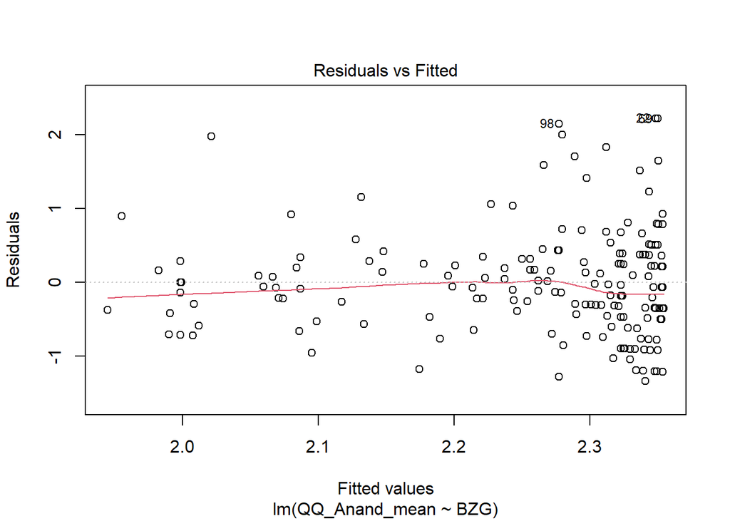

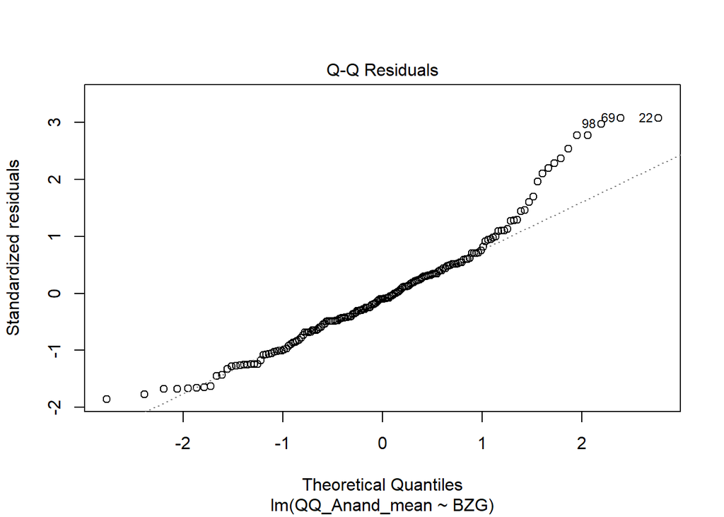

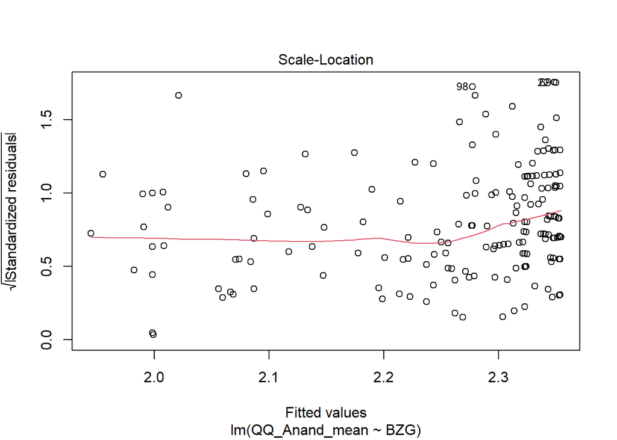

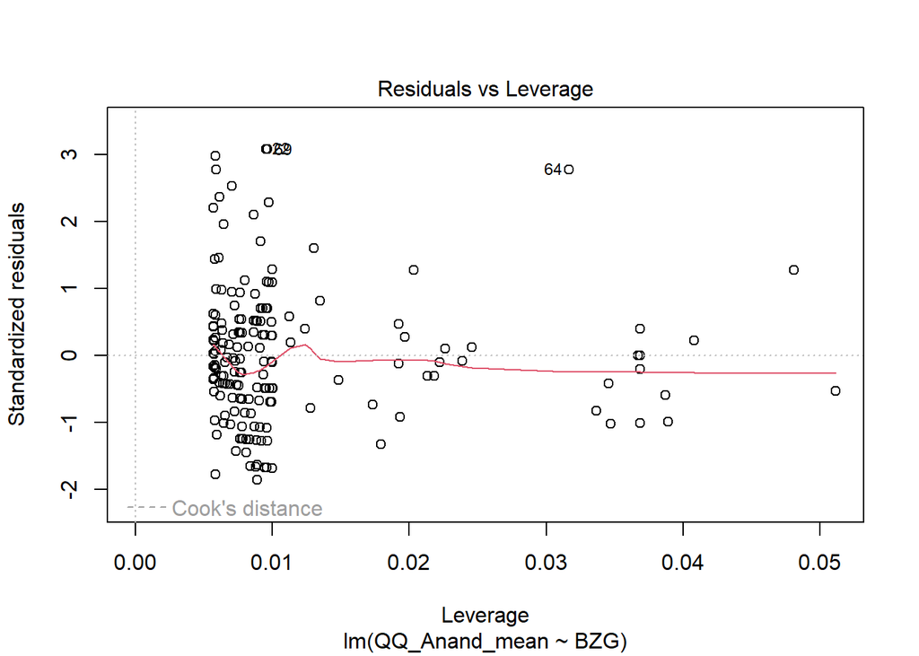

```r
lm_BZG <- lm(QQ_Anand_mean ~ BZG, data=d_work_lm)
plot(lm_BZG)
```

## Subset #2 erstellen

```r
subset_cor_NEU <- subset(d_work_lm,
                     select = c(ID, Alter, Geschlecht, Bildung, BZG, Beschaeftigungsart, Arbeitszeitmodell, Gehalt_n, Position_im_Unternehmen, Remotarbeit, IS_mean, CPE_mean, PS_mean, OC_A_mean, QQ_Anand_mean, QQ_Gesamt_mean, SL_mean))
```

```r
library(apaTables)
apa.cor.table(subset_cor_NEU, filename = "corr-com_NEU.doc", table.number = 2)
```

```
##
##
## Table 2
##
## Means, standard deviations, and correlations with confidence intervals
##
##
##   Variable                   M     SD    1           2            3
##   1. ID                      88.50 50.95
##
##   2. Alter                   40.26 13.38 .23**
##                                          [.09, .37]
##
##   3. Geschlecht              1.69  0.46  .13         -.01
##                                          [-.02, .27] [-.16, .14]
##
##   4. Bildung                 5.39  1.52  .01         -.14         .00
##                                          [-.14, .15] [-.28, .01]  [-.15, .15]
##
##   5. BZG                     11.20 12.22 .09         .66**        -.13
##                                          [-.06, .23] [.56, .73]   [-.27, .02]
##
##   6. Beschaeftigungsart      1.89  0.32  .11         .39**        -.01
##                                          [-.04, .26] [.25, .51]   [-.15, .14]
##
##   7. Arbeitszeitmodell       31.64 9.86  .02         -.09         -.14
##                                          [-.13, .17] [-.24, .06]  [-.28, .01]
##
##   8. Gehalt_n                2.95  1.15  .10         .26**        -.32**
##                                          [-.05, .25] [.12, .39]   [-.45, -.18]
##
##   9. Position_im_Unternehmen 0.21  0.41  -.00        .14          -.17*
##                                          [-.15, .15] [-.01, .28]  [-.31, -.02]
##
##   10. Remotarbeit            2.25  1.51  .08         -.06         .14
##                                          [-.07, .22] [-.21, .09]  [-.00, .29]
##
##   11. IS_mean                3.19  1.23  -.04        -.09         .08
##                                          [-.18, .11] [-.24, .06]  [-.07, .23]
##
```

[output cut: 163 more lines]

```
##
##
##
##
##
##   -.47**
##   [-.58, -.35]
##
##
## Note. M and SD are used to represent mean and standard deviation, respectively.
## Values in square brackets indicate the 95% confidence interval.
## The confidence interval is a plausible range of population correlations
## that could have caused the sample correlation (Cumming, 2014).
##  * indicates p < .05. ** indicates p < .01.
##
```

# Hierarchische Regression

## 1. Ebene

```r
lm0 <- lm(QQ_Anand_mean ~ Gehalt_n + Position_im_Unternehmen, data = d_work_lm)
summary(lm0)
```

```
##
## Call:
## lm(formula = QQ_Anand_mean ~ Gehalt_n + Position_im_Unternehmen,
##     data = d_work_lm)
##
## Residuals:
##      Min       1Q   Median       3Q      Max
## -1.40774 -0.44199 -0.03055  0.36236  2.27229
##
## Coefficients:
##                         Estimate Std. Error t value Pr(>|t|)
## (Intercept)              2.62495    0.15166  17.308   <2e-16 ***
## Gehalt_n                -0.10860    0.05085  -2.136   0.0341 *
## Position_im_Unternehmen -0.24012    0.14242  -1.686   0.0936 .
## ---
## Signif. codes:  0 '***' 0.001 '**' 0.01 '*' 0.05 '.' 0.1 ' ' 1
##
## Residual standard error: 0.7152 on 171 degrees of freedom
##   (2 Beobachtungen als fehlend gelöscht)
## Multiple R-squared:  0.06355,    Adjusted R-squared:  0.0526
## F-statistic: 5.802 on 2 and 171 DF,  p-value: 0.003646
```

## 2. Ebene

```r
lm01 <- lm(QQ_Anand_mean ~ scale(OC_A_mean) + Gehalt_n + Position_im_Unternehmen, data = d_work_lm)
summary(lm01)
```

```
##
## Call:
## lm(formula = QQ_Anand_mean ~ scale(OC_A_mean) + Gehalt_n + Position_im_Unternehmen,
##     data = d_work_lm)
##
## Residuals:
##      Min       1Q   Median       3Q      Max
## -1.19101 -0.34242 -0.04414  0.32848  1.83963
##
## Coefficients:
##                         Estimate Std. Error t value Pr(>|t|)
## (Intercept)              2.58594    0.11626  22.242  < 2e-16 ***
## scale(OC_A_mean)        -0.46615    0.04233 -11.011  < 2e-16 ***
## Gehalt_n                -0.10558    0.03896  -2.710  0.00742 **
## Position_im_Unternehmen -0.07110    0.11020  -0.645  0.51966
## ---
## Signif. codes:  0 '***' 0.001 '**' 0.01 '*' 0.05 '.' 0.1 ' ' 1
##
## Residual standard error: 0.548 on 170 degrees of freedom
##   (2 Beobachtungen als fehlend gelöscht)
## Multiple R-squared:  0.4534, Adjusted R-squared:  0.4438
## F-statistic:    47 on 3 and 170 DF,  p-value: < 2.2e-16
```

> nach dem Durchtesten der verschiedenen Variablen stellte sich heraus, dass OCA den höchsten Erklärungswert zu QQ beiträgt!

## 3. Ebene

```r
lm02 <- lm(QQ_Anand_mean ~ scale(OC_A_mean) + scale(CPE_mean) + Gehalt_n + Position_im_Unternehmen, data = d_work_lm)
summary(lm02)
```

```
##
## Call:
## lm(formula = QQ_Anand_mean ~ scale(OC_A_mean) + scale(CPE_mean) +
##     Gehalt_n + Position_im_Unternehmen, data = d_work_lm)
##
## Residuals:
##      Min       1Q   Median       3Q      Max
## -1.30935 -0.35485 -0.05014  0.32985  1.80733
##
## Coefficients:
##                         Estimate Std. Error t value Pr(>|t|)
## (Intercept)              2.57942    0.11050  23.342  < 2e-16 ***
## scale(OC_A_mean)        -0.31383    0.05316  -5.904 1.90e-08 ***
## scale(CPE_mean)         -0.23280    0.05310  -4.384 2.04e-05 ***
## Gehalt_n                -0.10691    0.03703  -2.887  0.00439 **
## Position_im_Unternehmen -0.02155    0.10534  -0.205  0.83817
## ---
## Signif. codes:  0 '***' 0.001 '**' 0.01 '*' 0.05 '.' 0.1 ' ' 1
##
## Residual standard error: 0.5208 on 169 degrees of freedom
##   (2 Beobachtungen als fehlend gelöscht)
## Multiple R-squared:  0.5092, Adjusted R-squared:  0.4976
## F-statistic: 43.84 on 4 and 169 DF,  p-value: < 2.2e-16
```

> nach dem Durchtesten der verschiedenen Variablen stellte sich heraus, dass CPE, neben OCA (2. Ebene) den höchsten Erklärungswert zu QQ beiträgt!

```r
confint(lm02)
```

```
##                              2.5 %      97.5 %
## (Intercept)              2.3612771  2.79756631
## scale(OC_A_mean)        -0.4187720 -0.20889120
## scale(CPE_mean)         -0.3376229 -0.12797169
## Gehalt_n                -0.1800147 -0.03381345
## Position_im_Unternehmen -0.2294947  0.18640047
```

## 4. Ebene

```r
lm03 <- lm(QQ_Anand_mean ~ scale(OC_A_mean) + scale(CPE_mean) + scale(SL_mean) + Gehalt_n + Position_im_Unternehmen, data = d_work_lm)
summary(lm03)
```

```
##
## Call:
## lm(formula = QQ_Anand_mean ~ scale(OC_A_mean) + scale(CPE_mean) +
##     scale(SL_mean) + Gehalt_n + Position_im_Unternehmen, data = d_work_lm)
##
## Residuals:
##      Min       1Q   Median       3Q      Max
## -1.36024 -0.35358 -0.04873  0.35315  1.86675
##
## Coefficients:
##                         Estimate Std. Error t value Pr(>|t|)
## (Intercept)              2.57054    0.11003  23.363  < 2e-16 ***
## scale(OC_A_mean)        -0.28305    0.05592  -5.062 1.08e-06 ***
## scale(CPE_mean)         -0.18877    0.05888  -3.206  0.00161 **
## scale(SL_mean)          -0.09519    0.05629  -1.691  0.09271 .
## Gehalt_n                -0.10242    0.03692  -2.774  0.00617 **
## Position_im_Unternehmen -0.04063    0.10537  -0.386  0.70029
## ---
## Signif. codes:  0 '***' 0.001 '**' 0.01 '*' 0.05 '.' 0.1 ' ' 1
##
## Residual standard error: 0.5179 on 168 degrees of freedom
##   (2 Beobachtungen als fehlend gelöscht)
## Multiple R-squared:  0.5174, Adjusted R-squared:  0.5031
## F-statistic: 36.03 on 5 and 168 DF,  p-value: < 2.2e-16
```

> nach dem Durchtesten der verschiedenen Variablen stellte sich heraus, dass SL neben CPE (3. Ebene) und OCA (2. Ebene) den höchsten Erklärungswert zu QQ beiträgt!

## 5. Ebene

```r
lm04 <- lm(QQ_Anand_mean ~ scale(OC_A_mean) + scale(CPE_mean) + scale(SL_mean) + scale(IS_mean) + Gehalt_n + Position_im_Unternehmen, data = d_work_lm)
summary(lm04)
```

```
##
## Call:
## lm(formula = QQ_Anand_mean ~ scale(OC_A_mean) + scale(CPE_mean) +
##     scale(SL_mean) + scale(IS_mean) + Gehalt_n + Position_im_Unternehmen,
##     data = d_work_lm)
##
## Residuals:
##      Min       1Q   Median       3Q      Max
## -1.42176 -0.34755 -0.04824  0.33735  1.81275
##
## Coefficients:
##                         Estimate Std. Error t value Pr(>|t|)
## (Intercept)              2.56578    0.11035  23.252  < 2e-16 ***
## scale(OC_A_mean)        -0.27913    0.05623  -4.964 1.69e-06 ***
## scale(CPE_mean)         -0.18857    0.05896  -3.198  0.00165 **
## scale(SL_mean)          -0.08865    0.05702  -1.555  0.12191
## scale(IS_mean)           0.03229    0.04270   0.756  0.45064
## Gehalt_n                -0.09925    0.03721  -2.668  0.00839 **
## Position_im_Unternehmen -0.06153    0.10906  -0.564  0.57340
## ---
## Signif. codes:  0 '***' 0.001 '**' 0.01 '*' 0.05 '.' 0.1 ' ' 1
##
## Residual standard error: 0.5186 on 167 degrees of freedom
##   (2 Beobachtungen als fehlend gelöscht)
## Multiple R-squared:  0.5191, Adjusted R-squared:  0.5018
## F-statistic: 30.04 on 6 and 167 DF,  p-value: < 2.2e-16
```

> nach dem Durchtesten der verschiedenen Variablen stellte sich heraus, dass IS neben SL (4. Ebene), CPE (3. Ebene) und OCA (2. Ebene) den höchsten Erklärungswert zu QQ beiträgt!

## 6. Ebene

```r
lm05 <- lm(QQ_Anand_mean ~ scale(OC_A_mean) + scale(CPE_mean) + scale(SL_mean) + scale(IS_mean) + scale(PS_mean) + Gehalt_n + Position_im_Unternehmen, data = d_work_lm)
summary(lm05)
```

```
##
## Call:
## lm(formula = QQ_Anand_mean ~ scale(OC_A_mean) + scale(CPE_mean) +
##     scale(SL_mean) + scale(IS_mean) + scale(PS_mean) + Gehalt_n +
##     Position_im_Unternehmen, data = d_work_lm)
##
## Residuals:
##      Min       1Q   Median       3Q      Max
## -1.41420 -0.35089 -0.04055  0.34063  1.76350
##
## Coefficients:
##                         Estimate Std. Error t value Pr(>|t|)
## (Intercept)              2.56376    0.11073  23.152  < 2e-16 ***
## scale(OC_A_mean)        -0.27597    0.05690  -4.850 2.82e-06 ***
## scale(CPE_mean)         -0.18102    0.06196  -2.922  0.00397 **
## scale(SL_mean)          -0.08402    0.05829  -1.441  0.15139
## scale(IS_mean)           0.02717    0.04463   0.609  0.54344
## scale(PS_mean)          -0.02237    0.05506  -0.406  0.68510
## Gehalt_n                -0.09824    0.03738  -2.628  0.00940 **
## Position_im_Unternehmen -0.06644    0.11001  -0.604  0.54667
## ---
## Signif. codes:  0 '***' 0.001 '**' 0.01 '*' 0.05 '.' 0.1 ' ' 1
##
## Residual standard error: 0.5199 on 166 degrees of freedom
##   (2 Beobachtungen als fehlend gelöscht)
## Multiple R-squared:  0.5196, Adjusted R-squared:  0.4993
## F-statistic: 25.64 on 7 and 166 DF,  p-value: < 2.2e-16
```

## ANOVA

```r
anova <- anova(lm0, lm01, lm02, lm03, lm04, lm05)
anova
```

```
## Analysis of Variance Table
##
## Model 1: QQ_Anand_mean ~ Gehalt_n + Position_im_Unternehmen
## Model 2: QQ_Anand_mean ~ scale(OC_A_mean) + Gehalt_n + Position_im_Unternehmen
## Model 3: QQ_Anand_mean ~ scale(OC_A_mean) + scale(CPE_mean) + Gehalt_n +
##     Position_im_Unternehmen
## Model 4: QQ_Anand_mean ~ scale(OC_A_mean) + scale(CPE_mean) + scale(SL_mean) +
##     Gehalt_n + Position_im_Unternehmen
## Model 5: QQ_Anand_mean ~ scale(OC_A_mean) + scale(CPE_mean) + scale(SL_mean) +
##     scale(IS_mean) + Gehalt_n + Position_im_Unternehmen
## Model 6: QQ_Anand_mean ~ scale(OC_A_mean) + scale(CPE_mean) + scale(SL_mean) +
##     scale(IS_mean) + scale(PS_mean) + Gehalt_n + Position_im_Unternehmen
##   Res.Df    RSS Df Sum of Sq        F    Pr(>F)
## 1    171 87.458
## 2    170 51.049  1    36.409 134.6964 < 2.2e-16 ***
## 3    169 45.836  1     5.213  19.2853 1.999e-05 ***
## 4    168 45.069  1     0.767   2.8375   0.09396 .
## 5    167 44.915  1     0.154   0.5689   0.45178
## 6    166 44.870  1     0.045   0.1650   0.68510
## ---
## Signif. codes:  0 '***' 0.001 '**' 0.01 '*' 0.05 '.' 0.1 ' ' 1
```

> Das beste Modell mit dem höchsten Erklärungswert ist Modell lm02 mit CPE und OCA mit QQ und den beiden Kontrollvariablen. Um das Konstrukt QQ zu erklären, liefern OCA und CPE den höchsten Gehalt.

# Hypothesenprüfung - Korrelation

## H1: Kultur für psychologisches Empowerment - `CPE`

```r
cor_result_H1 <- cor.test(d_work_lm$CPE_mean, d_work_lm$QQ_Anand_mean, use = "complete.obs")
```

```r
cor_result_H1$estimate %>% round(2)
```

```
##   cor
## -0.61
```

```r
cor_result_H1$conf.int %>% round(2)
```

```
## [1] -0.70 -0.51
## attr(,"conf.level")
## [1] 0.95
```

```r
cor_result_H1$p.value
```

```
## [1] 1.370491e-19
```

### Effektgröße beschreiben

```r
effectsize::interpret_r(-0.6136367, rules = "cohen1988")
```

```
## [1] "large"
## (Rules: cohen1988)
```

## H2: Organisationales Commitment - affektiv `OCA`

```r
cor_result_H2 <- cor.test(d_work_lm$OC_A_mean, d_work_lm$QQ_Anand_mean, use = "complete.obs")
```

```r
cor_result_H2$estimate %>% round(2)
```

```
##   cor
## -0.65
```

```r
cor_result_H2$conf.int %>% round(2)
```

```
## [1] -0.72 -0.55
## attr(,"conf.level")
## [1] 0.95
```

```r
cor_result_H2$p.value
```

```
## [1] 3.380537e-22
```

### Effektgröße beschreiben

```r
effectsize::interpret_r(-0.6463683, rules = "cohen1988")
```

```
## [1] "large"
## (Rules: cohen1988)
```

## H3: Psychologische Sicherheit `PS`

```r
cor_result_H3 <- cor.test(d_work_lm$PS_mean, d_work_lm$QQ_Anand_mean, use = "complete.obs")
```

```r
cor_result_H3$estimate %>% round(2)
```

```
##   cor
## -0.47
```

```r
cor_result_H3$conf.int %>% round(2)
```

```
## [1] -0.58 -0.34
## attr(,"conf.level")
## [1] 0.95
```

```r
cor_result_H3$p.value
```

```
## [1] 5.784166e-11
```

### Effektgröße beschreiben

```r
effectsize::interpret_r(-0.4679921, rules = "cohen1988")
```

```
## [1] "moderate"
## (Rules: cohen1988)
```

## H4: Irritation `IS`

```r
cor_result_H4 <- cor.test(d_work_lm$IS_mean, d_work_lm$QQ_Anand_mean, use = "complete.obs")
```

```r
cor_result_H4$estimate %>% round(2)
```

```
##  cor
## 0.21
```

```r
cor_result_H4$conf.int %>% round(2)
```

```
## [1] 0.06 0.34
## attr(,"conf.level")
## [1] 0.95
```

```r
cor_result_H4$p.value
```

```
## [1] 0.006201247
```

### Effektgröße beschreiben

```r
effectsize::interpret_r(0.2055619, rules = "cohen1988")
```

```
## [1] "small"
## (Rules: cohen1988)
```

## H5: Servant Leadership `SL`

```r
cor_result_H5 <- cor.test(d_work_lm$SL_mean, d_work_lm$QQ_Anand_mean, use = "complete.obs")
```

```r
cor_result_H5$estimate %>% round(2)
```

```
##   cor
## -0.55
```

```r
cor_result_H5$conf.int %>% round(2)
```

```
## [1] -0.65 -0.44
## attr(,"conf.level")
## [1] 0.95
```

```r
cor_result_H5$p.value
```

```
## [1] 1.72892e-15
```

### Effektgröße beschreiben

```r
effectsize::interpret_r(-0.553062, rules = "cohen1988")
```

```
## [1] "large"
## (Rules: cohen1988)
```

# H2.2: Moderation: CPE moderiert den Zusammenhang von OCA und QQ

```r
lm06 <- lm(QQ_Anand_mean ~ scale(OC_A_mean)*scale(CPE_mean), data=d_work_lm)
summary(lm06)
```

```
##
## Call:
## lm(formula = QQ_Anand_mean ~ scale(OC_A_mean) * scale(CPE_mean),
##     data = d_work_lm)
##
## Residuals:
##      Min       1Q   Median       3Q      Max
## -1.67371 -0.35216 -0.03223  0.32281  1.78792
##
## Coefficients:
##                                  Estimate Std. Error t value Pr(>|t|)
## (Intercept)                       2.22143    0.04676  47.506  < 2e-16 ***
## scale(OC_A_mean)                 -0.29892    0.05439  -5.496 1.38e-07 ***
## scale(CPE_mean)                  -0.22721    0.05441  -4.176 4.71e-05 ***
## scale(OC_A_mean):scale(CPE_mean)  0.05424    0.03684   1.473    0.143
## ---
## Signif. codes:  0 '***' 0.001 '**' 0.01 '*' 0.05 '.' 0.1 ' ' 1
##
## Residual standard error: 0.5295 on 172 degrees of freedom
## Multiple R-squared:  0.4848, Adjusted R-squared:  0.4758
## F-statistic: 53.95 on 3 and 172 DF,  p-value: < 2.2e-16
```

> Keine signifikante Moderation!

```r
confint(lm06)
```

```
##                                        2.5 %     97.5 %
## (Intercept)                       2.12912622  2.3137255
## scale(OC_A_mean)                 -0.40627317 -0.1915681
## scale(CPE_mean)                  -0.33460819 -0.1198104
## scale(OC_A_mean):scale(CPE_mean) -0.01846704  0.1269502
```

```r
library(interactions)
```

```r
plot_lm06 <-interact_plot(model=lm06, pred=OC_A_mean, modx=CPE_mean,
              interval = TRUE)
```

```
## Using data d_work_lm from global environment. This could cause incorrect
## results if d_work_lm has been altered since the model was fit. You can
## manually provide the data to the "data =" argument.
```

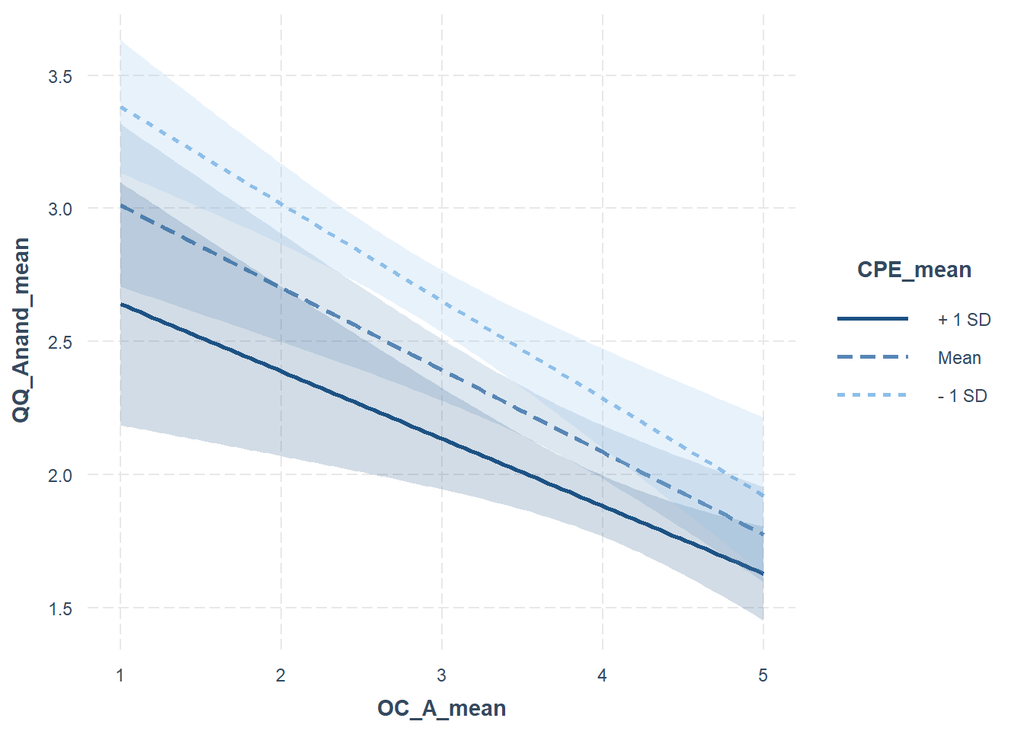

```r
plot_lm06
```

```r
svg("H2.2.svg", width = 7, height = 5)
print(plot_lm06)
dev.off()
```

# H2.1: Moderation: Alter moderiert den Zusammenhang von OCA und QQ-Gesamt

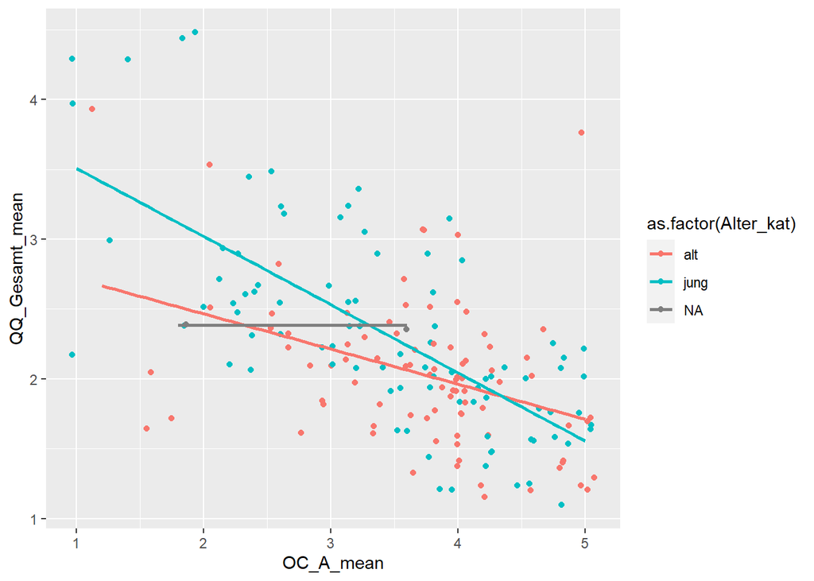

```r
ggplot(d_work_lm)+
  geom_jitter(mapping = aes(x=OC_A_mean, y=QQ_Gesamt_mean, color=as.factor(Alter_kat)))+
  geom_smooth(mapping = aes(x=OC_A_mean, y=QQ_Gesamt_mean, color=as.factor(Alter_kat)), method = "lm", se=FALSE)
```

## QQ_Anand

```r
lm07 <- lm(QQ_Anand_mean ~ OC_A_mean*Alter_kat, data=d_work_lm)
summary(lm07)
```

```
##
## Call:
## lm(formula = QQ_Anand_mean ~ OC_A_mean * Alter_kat, data = d_work_lm)
##
## Residuals:
##      Min       1Q   Median       3Q      Max
## -1.23827 -0.36525 -0.00935  0.28869  1.99065
##
## Coefficients:
##                         Estimate Std. Error t value Pr(>|t|)
## (Intercept)              3.27496    0.27237  12.024  < 2e-16 ***
## OC_A_mean               -0.31640    0.07170  -4.413 1.81e-05 ***
## Alter_katjung            1.11431    0.33578   3.319  0.00111 **
## OC_A_mean:Alter_katjung -0.26318    0.09023  -2.917  0.00401 **
## ---
## Signif. codes:  0 '***' 0.001 '**' 0.01 '*' 0.05 '.' 0.1 ' ' 1
##
## Residual standard error: 0.5448 on 170 degrees of freedom
##   (2 Beobachtungen als fehlend gelöscht)
## Multiple R-squared:  0.4601, Adjusted R-squared:  0.4506
## F-statistic:  48.3 on 3 and 170 DF,  p-value: < 2.2e-16
```

```r
confint(lm07)
```

```
##                              2.5 %     97.5 %
## (Intercept)              2.7373003  3.8126292
## OC_A_mean               -0.4579419 -0.1748649
## Alter_katjung            0.4514827  1.7771444
## OC_A_mean:Alter_katjung -0.4412825 -0.0850684
```

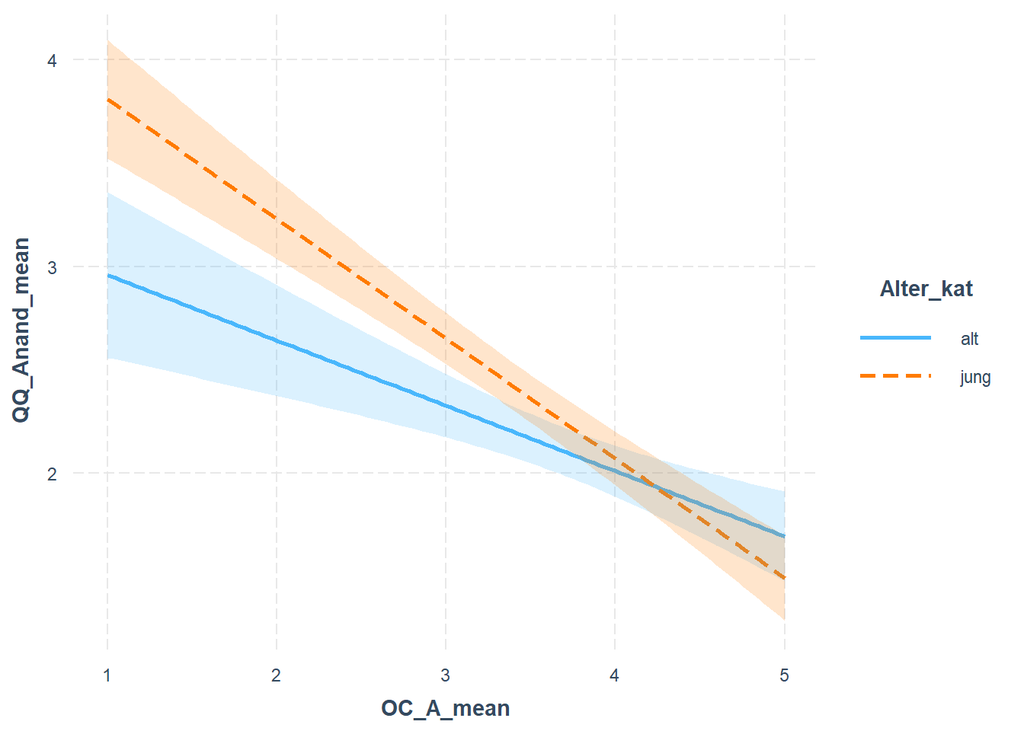

```r
plot_lm07 <- interact_plot(model=lm07, pred=OC_A_mean, modx=Alter_kat,
              interval = TRUE)
plot_lm07
```

```r
svg("H2.1.svg", width = 7, height = 5)
print(plot_lm07)
dev.off()
```